# YearUp Labor Project: Replicating Code

Parker Zhao, Angie Peng, Edmund Zhou, Michael Saadine, Alisha Anderson, Ricky Toh Wen Xian

May 29, 2021

```r
# Ensure that pacman is installed for package management and loading.
if (!require("pacman")) install.packages("pacman")
pacman::p_load(tidyverse) # for data reading wrangling and visualization
```

```r
# for enabling dataframe manipulation
pacman::p_load(dplyr)
# for modeling, transforming, and visualizing data
pacman::p_load(tidyverse)
# for simplifying the process of creating tidy dat
pacman::p_load(tidyr)
# for working with tabular data
pacman::p_load(data.table)
pacman::p_load(devtools)
# for data visualization
pacman::p_load(ggplot2)
# for plotting correlations
pacman::p_load(corrplot)  # Correlations (0.84)
# provides support to ggplot2 for labeling graphs
pacman::p_load(directlabels)
# for streamlining the model training process
pacman::p_load(caret)
# for fitting a generalized linear model
pacman::p_load(glmnet)
# for providing a general-purpose tool for dynamic report generation
pacman::p_load(knitr)
# for providing a prettier RMarkdown (1.0.1)
pacman::p_load(kableExtra)
pacman::p_load(stargazer)
options(scipen = 1000)
pacman::p_load('fastDummies')
pacman::p_load(Formula)
source_url("https://raw.githubusercontent.com/MatthieuStigler/Misconometrics/master/Gelbach_decompo/dec_covar.R")
```

# Part I: Wage Change Model

In this project, we want to measure and analyze the returns to participating in the YearUp labor training program. Specifically, we ask the question: what is the increase in participants’ earnings after they participated in the program, compared to what their earnings would have been had they not participated? We are then interested to know whether these returns differ by subgroups.

The data we received from Year Up (YU) includes the records of 1,469 individuals who *completed* the program. We know their pre- and post-YU wages, occupations, and a few socio-economic characteristics. However, we do not have a control group (for example, a group of applicants who applied to Year Up but did not get into the program and who have similar characteristics to the Year Up participants). To build a counterfactual for the YU participants, we start by building a wage prediction model using the Current Population Survey (CPS), which represents a sample of the general U.S population. We preprocess the CPS sample used for wage prediction model to make it look more like our YU participant sample by filtering out individuals from the CPS who do not look like YU participants.

We use the wage prediction model to predict the counterfactual changes in earnings for the YU participants. After obtaining the counterfactuals, we build a YU training program treatment effect model. For the treatment sample, we use the actual data on YU participants (including the post-training earnings). For the control sample, we clone the YU sample with all its characteristics (excluding the post-training earnings) and use the counterfactual obtained by the wage prediction model instead of the actual post-training earnings.

Finally, we compare the mean differences in actual (post-treatment) earnings changes with the counterfactual changes to get our best estimate of the Year Up training program returns across all participants as well as for participant subgroups. We use various observable characteristics of the YU participants to create the participant subgroups, such as: gender, race, location etc.

## Steps

We will build a model to predict year-over-year change in wages, using the CPS data. We will take the following steps:

1. We start by *loading and getting to know the data*. This includes: loading all the necessary R packages, loading the data, familiarizing ourselves with the data through the codebooks and summary statistics. As described in the introduction, we use an external data set because we are interested in building a “counterfactual” - i.e. what would have happened to Year Up participants’ yearly earnings had they not participated in the training program? To that end, we use the CPS dataset because it represents a more general population in order to create a sample of non-treated individuals.
2. Transforming and pre-processing the data: to prepare the dataset for the training of the model, we get rid of outliers and other unnecessary data points, log transform the outcome variable as well as scale and center (i.e. standardize) the data used as inputs to the prediction models.
3. The next step is to build and evaluate different prediction models for year-over-year wage changes using the CPS data. Note that we only use the variables in the CPS data that we also have in the Year Up data. We start with a linear model and then build a lasso, ridge, and random forest model. For each of those, we train the model on a training set and test its performance on a test set. We also compare the performance across different models.
4. The final step of the tutorial is a calibration exercise. Here, we are interested in figuring out whether our predictions are well-calibrated against the true values, i.e. whether on average, our predictions are correct or biased. We do this calibration exercise for all the different models and then use the best model to perform calibration analysis on subgroups of participants. This will turn out to be important for later parts in this project - since we want to analyze heterogeneous treatment effects, it is important to make sure our predictions are well-calibrated both overall as well as on the population subgroups in question.

## Data

We use the Current Population Survey (CPS) to build our wage prediction model. This is a representative sample of the entire US population and is a large monthly household survey. Originally, the data includes 8 waves per household in a rotation scheme that spans one year and fourth months in total: a household first gets interviewed during four consecutive months, which is repeated after 8 months, and then again gets interviewed for four months. We only keep two waves per individual at two points that are one year apart. You can find more information about the dataset, its original structure, and variables here: https://cps.ipums.org/cps/.

We begin by reading in the CPS data as well as the task and county-level data. We then select the columns from the county-level dataset which are relevant for our analysis and merge this dataset with task and CPS datasets. Finally, we filter out all the CPS data observations dating before 2005 because we only have data on YU participants from 2005 onwards and we want the time periods for the CPS and YU samples to match in order to build a counterfactual properly; i.e. we can “help” the model to more accurately predict on our target data, in this case the YU data, by training it on data that resembles the target data more closely. This leaves us with a dataset of just under 400,000 individuals, which is still a sizable number of individuals for building our wage prediction model.

In addition to the CPS data, we will be enriching the dataset by merging auxillary data that characterize the locations and occupations of the individuals in the data. We will then be adding the same data to the YU data. The auxillary occupation data stems from Autor and Dorn’s 2013 paper: “The Growth of Low-Skill Service Jobs and the Polarization of the US Labor Market” and described the routine, manual and abstract task intensity of occupations. More information about the data can be found [here](https://www.ddorn.net/data.htm). The auxillary location data comes from “Neighborhood Characteristics by County” in Opportunity Insight’s data library which can be found [here](https://opportunityinsights.org/data/).

```r
data_folder <- "Datasets"
save_folder <- "intermediate"

# Load CPS data
cps_7018 <- fread(paste(data_folder, "cps_7018_wide_earn.csv", sep="/"))

# Load task data
tasks<-fread(paste(data_folder, "tasks_1990dd.csv", sep="/"))

# Load county-level data
county_vars <- fread(paste(data_folder, "count_level_covars.csv", sep="/"))

# Select the relevant county variables to be merged with the CPS data
county_vars<-county_vars %>%
  select(cty, county_name, cty_pop2000, cz, cz_name, cz_pop2000, intersects_msa, cs00_seg_inc, cs00_seg_inc_pov25, cs00_seg_inc_aff75, cs_race_theil_2000, gini99, poor_share, inc_share_1perc, frac_middleclass, rel_tot, cs_frac_black, cs_frac_hisp, unemp_rate, pop_d_2000_1980, lf_d_2000_1980, cs_labforce, cs_elf_ind_man, cs_born_foreign, mig_inflow, mig_outflow, pop_density, frac_traveltime_lt15, hhinc00, median_house_value, cs_educ_ba, cs_fam_wkidsinglemom, crime_total, subcty_exp_pc, taxrate, tax_st_diff_top20)

# Merge county variables with the CPS and task data
cps_7018 <- merge(cps_7018,county_vars, by.x="county_1", by.y = "cty")
cps_7018 <- merge(tasks,cps_7018,by.x="occ1990", by.y="occ1990_1")

# Filter out observations dating before 2005
cps_7018 <- cps_7018  %>%
  dplyr::filter(year_1>2005)
```

We continue processing the CPS data by filtering out all occupations that do not match the YU participants’ occupations. To do so, we begin by defining the `yu_occ` variable that specifies all the occupation codes corresponding to the occupations of YU participants. We then filter out all observations in the CPS data that do not match any of the occupations of the YU participants.

Finally, we select and name the relevant CPS data columns that we will be using in our analysis. Since we will be wanting to predict on the Year Up data later, we need to make sure that (1) all variables we want to use in our wage model exist in both data sets and (2) all variables are defined and scaled the same way across both data sets. It is no use training our model on a variable that does not exist in the target data.

```r
# Specify occupation codes corresponding to the occupations of YU participants
yu_occ <- c(0,1007,1050,2000,2800,3420,4020,4130,4720,4740,4760,4850,4940,5240,5300,5400,9620,160,650,2016,4060,4140,4700,5350,5860,6440,6930,8340,110,1060,2910,4800,20,140,205,230,310,620,640,700,725,735,1220,2630,2720,2840,3255,3640,3800,3850,3910,3930,3955,4000,4030,4110,4120,4150,4220,4340,4600,4610,4620,4640,4710,5110,5120,5260,5520,5620,5700,5900,6050,6355,7000,7130,7720,7800,7810,7840,8740,8950,9300,9630,9640,420,930,1550,2825,4050,4420,4430,5310,5320,5600,5610,7020,7200,7710,9610,1006,2830,4010,4200,4250,4820,4900,5000,5020,4510,9350,565,2810,8360,9415,5630,6320,530,810,3600,4750,5510,5830,6420,7700,9130,4350,5220,5810,7730,2310,8255,60,540,726,910,1030,1107,2540,2600,2710,2860,2900,3645,5100,5500,5800,6230,7120,7150,7315,7420,8810,8830,137,410,1910,2440,3648,4530,4920,5150,5550,5850,7350,4830,6260,1010,740,1020,50,120,850,3510,4240,7010,9360)

# Filter out all CPS observations that do not match any of the occupations of the YU participants
cps_df<-cps_7018 %>%
  dplyr::filter(occ2010_1 %in% yu_occ)

# Select and name the relevant CPS data columns for our analysis
cps_df<- cps_df %>%
  select(d_earn,
         occ2010_1,year_1,cpsidp,occ1digit_1,age_1,age2_1,sex_1,race_white_1,race_black_1,race_asian_1,
         edu_num_1, experience_1,experience2_1,metfips_1,
         RTIa,task_abstract,task_routine,task_manual,county_1,region_large_1,
         county_name,cty_pop2000,cz,cz_name,cz_pop2000,intersects_msa,
         cs00_seg_inc,cs00_seg_inc_pov25,cs00_seg_inc_aff75,
         cs_race_theil_2000,gini99,poor_share,inc_share_1perc,
         frac_middleclass,rel_tot,cs_frac_black,
         cs_frac_hisp,unemp_rate,pop_d_2000_1980,lf_d_2000_1980,
         cs_labforce,cs_elf_ind_man,cs_born_foreign,mig_inflow,
         mig_outflow,pop_density,frac_traveltime_lt15,hhinc00,
         median_house_value,cs_educ_ba, cs_fam_wkidsinglemom,crime_total,subcty_exp_pc,
         taxrate,tax_st_diff_top20, real_yearly_earnings_1, real_yearly_earnings_2)

colnames(cps_df)<- c( "d_earn", "occ2010","year","cpsidp","occ1digit","age","age2","sex",
                     "race_white","race_black","race_asian","edu_num" ,"experience","experience2",
                     "metfips", "RTIa","task_abstract","task_routine",
                     "task_manual","county","region_large",
                    "county_name","cty_pop2000","cz","cz_name","cz_pop2000","intersects_msa",
                    "cs00_seg_inc","cs00_seg_inc_pov25","cs00_seg_inc_aff75",
                    "cs_race_theil_2000","gini99","poor_share","inc_share_1perc",
                    "frac_middleclass","rel_tot","cs_frac_black",
                    "cs_frac_hisp","unemp_rate","pop_d_2000_1980","lf_d_2000_1980",
                    "cs_labforce","cs_elf_ind_man","cs_born_foreign","mig_inflow",
                    "mig_outflow","pop_density","frac_traveltime_lt15","hhinc00",
                    "median_house_value","cs_educ_ba",
                    "cs_fam_wkidsinglemom","crime_total","subcty_exp_pc",
                    "taxrate","tax_st_diff_top20", "real_yearly_earnings_1", "real_yearly_earnings_2")
```

### Codebook for the CPS data

Before diving into any analysis, the first step is always to get to know one’s sample data. To this end, we look at the codebook and make some summary statistics on the sample.

| Variable name | Description |
| --- | --- |
| d_earn | Difference in earnings at t+1 and t |
| real_yearly_earnings_t | Earnings at year t |
| male | Male |
| race_white | Race: White |
| race_asian | Race: Asian |
| race_black | Race: Black |
| edu_num | Years of Education |
| experience | Years of Experience |
| experience2 | Years of Experience Squared |
| age | Age |
| age2 | Age Squared |
| RTIa | Previous occupation: task index |
| task_abstract | Previous occupation: abstract task measure |
| task_manual | Previous occupation: manual task measure |
| task_routine | Previous occupation: routine task measure |
| Occupation Groups (previous occupation) |  |
| occ1digit_art_sports_media | Arts, Design, Entertainment, Sports, and Media |
| occ1digit_building_cleaning | Building and Grounds Cleaning and Maintenance |
| occ1digit_business_op | Business Operations Specialists |
| occ1digit_community | Community and Social Services |
| occ1digit_computer_mathematica | Computer and Mathematical |
| occ1digit_construction | Construction |
| occ1digit_educ | Education, Training, and Library |
| occ1digit_farm_fish_forest | Farming, Fisheries, and Forestry |
| occ1digit_finacial_spec | Financial Specialists |
| occ1digit_food_serving | Food Preparation and Serving |
| occ1digit_healthcare_supp | Healthcare Support |
| occ1digit_healthcare_tech | Healthcare Practitioners and Technicians |
| occ1digit_install_maint_rep | Installation, Maintenance, and Repair |
| occ1digit_life_physical_ssc | Life, Physical, and Social Science |
| occ1digit_management | Management in Business, Science, and Arts |
| occ1digit_offic_admin | Office and Administrative Support |
| occ1digit_pers_care | Personal Care and Service |
| occ1digit_production | Production |
| occ1digit_protective_serv | Protective Service |
| occ1digit_sales | Sales and Related |
| occ1digit_technician | Technicians |
| occ1digit_transport | Transportation and Material Moving |
| Location characteristics |  |
| cty_pop2000 | County Population in 2000 |
| cz_pop2000 | Commuting Zone Population in 2000 |
| intersects_msa | Urban Area |
| cs00_seg_inc | Income Segregation |
| cs00_seg_inc_pov25 | Segregation of Poverty (< p25) |
| cs00_seg_inc_aff75 | Segregation of Affluence (>p75) |
| cs_race_theil_2000 | Racial Segregation |
| gini99 | Gini Index Within Bottom 99% |
| poor_share | Poverty Rate |
| inc_share_1perc | Top 1% Income Share |
| frac_middleclass | Fraction Middle Class (p25-p75) |
| scap_ski90pcm | Social Capital Index |
| rel_tot | Percent Religious |
| cs_frac_black | Percent Black |
| cs_frac_hisp | Percent Hispanic |
| unemp_rate | Unemployment Rate in 2000 |
| pop_d_2000_1980 | Percent Change in Population 1980-2000 |
| lf_d_2000_1980 | Percent Change in Labor Force 1980-2000 |
| cs_labforce | Labor Force Participation |
| cs_elf_ind_man | Share Working in Manufacturing |
| cs_born_foreign | Percent Foreign Born |
| mig_inflow | Migration Inflow Rate |
| mig_outflow | Migration Outflow Rate |
| pop_density | Population Density |
| frac_traveltime_lt15 | Fraction with Commute < 15 Min |
| hhinc00 | Mean Household Income |
| median_house_value | Median House Value |
| ccd_exp_tot | School Expenditure per Student |
| ccd_pup_tch_ratio | Student-Teacher Ratio |
| score_r | Test Score Percentile (Income Adjusted) |
| dropout_r | High School Dropout Rate (Income Adjusted) |
| cs_educ_ba | Percent College Grads |
| tuition | College Tuition |
| gradrate_r | Percent College Grads |
| e_rank_b | Absolute Mobility (Expected Rank at p25) |
| cs_fam_wkidsinglemom | Fraction of Children with Single Mother |
| crime_total | Total Crime Rate |
| subcty_exp_pc | Local Government Expenditures |
| taxrate | Local Tax Rate |
| tax_st_diff_top20 | Tax Progressivity |
| region_large | 4 Regions |

### Summary Statistics for the CPS data

The summary statistics help us get a better understanding of the numerical variables in terms of their mean, median, standard deviation, lowest and highest values as well as lower and upper quartiles.

```r
# Make a data.frame containing summary statistics of interest
cps_dfsum<-cps_df %>% dplyr::select(d_earn, real_yearly_earnings_1, real_yearly_earnings_2, where(is.numeric), -c(RTIa, occ2010, cpsidp, county, cz, metfips))
summ_stats <- fBasics::basicStats(cps_dfsum)
summ_stats <- as.data.frame(t(summ_stats))
# Rename some of the columns for convenience
summ_stats <- summ_stats[c("Mean", "Stdev", "Minimum", "1. Quartile", "Median",  "3. Quartile", "Maximum")]
colnames(summ_stats)[colnames(summ_stats) %in% c('1. Quartile', '3. Quartile')] <- c('Lower quartile', 'Upper quartile')
```

```r
# Pretty-printing in HTML
summ_stats_table <- kable(summ_stats, "html", digits = 2)
kable_styling(summ_stats_table,bootstrap_options=c("striped", "hover", "condensed", "responsive"),
              full_width=FALSE)
```

|  | Mean | Stdev | Minimum | Lower quartile | Median | Upper quartile | Maximum |
| --- | --- | --- | --- | --- | --- | --- | --- |
| d_earn | 760.82 | 34819.26 | -1331543.28 | -6858.03 | 160.47 | 8545.82 | 1223313.13 |
| real_yearly_earnings_1 | 38634.06 | 36548.89 | 0.00 | 16874.04 | 30385.63 | 50545.70 | 1360442.64 |
| real_yearly_earnings_2 | 39394.88 | 37167.65 | 0.00 | 17479.99 | 31135.59 | 51132.13 | 1275415.78 |
| year | 2012.18 | 3.97 | 2006.00 | 2009.00 | 2012.00 | 2016.00 | 2019.00 |
| age | 42.14 | 14.19 | 15.00 | 30.00 | 42.00 | 53.00 | 85.00 |
| age2 | 1976.85 | 1236.86 | 225.00 | 900.00 | 1764.00 | 2809.00 | 7225.00 |
| sex | 0.50 | 0.50 | 0.00 | 0.00 | 0.00 | 1.00 | 1.00 |
| race_white | 0.78 | 0.42 | 0.00 | 1.00 | 1.00 | 1.00 | 1.00 |
| race_black | 0.12 | 0.32 | 0.00 | 0.00 | 0.00 | 0.00 | 1.00 |
| race_asian | 0.00 | 0.00 | 0.00 | 0.00 | 0.00 | 0.00 | 0.00 |
| edu_num | 13.67 | 2.21 | 9.00 | 12.00 | 13.00 | 16.00 | 22.00 |
| experience | 22.48 | 14.08 | 0.00 | 11.00 | 22.00 | 33.00 | 70.00 |
| experience2 | 703.36 | 703.57 | 0.00 | 121.00 | 484.00 | 1089.00 | 4900.00 |
| task_abstract | 2.98 | 2.22 | 0.00 | 1.52 | 2.06 | 4.58 | 7.62 |
| task_routine | 3.75 | 2.25 | 1.25 | 1.89 | 3.00 | 5.06 | 8.54 |
| task_manual | 1.07 | 1.26 | 0.00 | 0.10 | 0.47 | 2.15 | 5.85 |
| region_large | 2.74 | 1.13 | 1.00 | 2.00 | 3.00 | 4.00 | 4.00 |
| cty_pop2000 | 1266130.89 | 2094773.82 | 76019.00 | 255602.00 | 572059.00 | 1334544.00 | 9519338.00 |
| cz_pop2000 | 4056180.66 | 4767332.15 | 130138.00 | 834343.00 | 2393183.00 | 4974945.00 | 16393360.00 |
| intersects_msa | 1.00 | 0.06 | 0.00 | 1.00 | 1.00 | 1.00 | 1.00 |
| cs00_seg_inc | 0.09 | 0.03 | 0.01 | 0.07 | 0.09 | 0.11 | 0.16 |
| cs00_seg_inc_pov25 | 0.07 | 0.03 | 0.01 | 0.05 | 0.08 | 0.09 | 0.15 |
| cs00_seg_inc_aff75 | 0.10 | 0.04 | 0.01 | 0.07 | 0.10 | 0.13 | 0.20 |
| cs_race_theil_2000 | 0.19 | 0.11 | 0.01 | 0.12 | 0.20 | 0.25 | 0.54 |
| gini99 | 0.47 | 0.12 | 0.23 | 0.39 | 0.45 | 0.52 | 1.09 |
| poor_share | 0.12 | 0.05 | 0.02 | 0.08 | 0.11 | 0.14 | 0.36 |
| inc_share_1perc | 0.15 | 0.06 | 0.05 | 0.10 | 0.14 | 0.18 | 0.54 |
| frac_middleclass | 0.48 | 0.06 | 0.29 | 0.45 | 0.48 | 0.52 | 0.66 |
| rel_tot | 49.09 | 12.33 | 22.18 | 39.73 | 47.55 | 57.81 | 89.93 |
| cs_frac_black | 12.25 | 13.42 | 0.15 | 2.70 | 8.82 | 15.36 | 66.72 |
| cs_frac_hisp | 14.36 | 15.52 | 0.51 | 3.29 | 7.79 | 21.96 | 94.28 |
| unemp_rate | 0.05 | 0.01 | 0.02 | 0.04 | 0.04 | 0.05 | 0.17 |
| pop_d_2000_1980 | 0.42 | 0.53 | -0.17 | 0.13 | 0.27 | 0.56 | 5.99 |
| lf_d_2000_1980 | 0.48 | 0.57 | -0.17 | 0.15 | 0.34 | 0.64 | 6.91 |
| cs_labforce | 0.65 | 0.05 | 0.43 | 0.61 | 0.65 | 0.68 | 0.79 |
| cs_elf_ind_man | 0.12 | 0.06 | 0.02 | 0.07 | 0.11 | 0.15 | 0.43 |
| cs_born_foreign | 13.36 | 10.80 | 0.76 | 4.78 | 9.83 | 19.01 | 46.13 |
| mig_inflow | 0.04 | 0.02 | 0.01 | 0.03 | 0.04 | 0.05 | 0.15 |
| mig_outflow | 0.04 | 0.01 | 0.01 | 0.03 | 0.04 | 0.05 | 0.14 |
| pop_density | 2832.74 | 7630.14 | 11.65 | 286.24 | 817.03 | 1957.42 | 66940.08 |
| frac_traveltime_lt15 | 0.26 | 0.08 | 0.10 | 0.21 | 0.25 | 0.31 | 0.53 |
| hhinc00 | 41860.77 | 8752.52 | 20099.17 | 36818.37 | 39875.12 | 46209.23 | 71794.66 |
| median_house_value | 214883.26 | 131231.28 | 63584.10 | 139831.70 | 183154.20 | 277797.20 | 1333001.33 |
| cs_educ_ba | 27.00 | 8.70 | 9.90 | 20.90 | 25.90 | 30.80 | 60.20 |
| cs_fam_wkidsinglemom | 0.22 | 0.08 | 0.09 | 0.17 | 0.22 | 0.25 | 0.52 |
| crime_total | 0.01 | 0.00 | 0.00 | 0.01 | 0.01 | 0.01 | 0.02 |
| subcty_exp_pc | 2752.34 | 1509.89 | 0.00 | 1911.67 | 2486.30 | 3226.90 | 9594.66 |
| taxrate | 0.03 | 0.01 | 0.00 | 0.02 | 0.02 | 0.03 | 0.10 |
| tax_st_diff_top20 | 1.81 | 2.55 | 0.00 | 0.00 | 0.00 | 2.66 | 7.22 |

### Transform and pre-process the data

Before building a wage prediction model by training it on the CPS data, we familiarize ourselves with the CPS data and investigate it for potential outliers that could impact the robustness of our wage prediction model. An easy way to perform initial outlier analysis is to plot a histogram of the variable of interest where we put the values of the variable of interest (or bins representing a range of values) on the x-axis and the count of observations for each value, or bin of values, on the y-axis. In this case, we plot histogram of the CPS data variables of interest `d_earn`, which is the yearly difference in wages, as well as `real_yearly_earnings_1` and `real_yearly_earnings_2`, which we use to compute the yearly earnings difference `d_earn`. We then observe the histograms to identify any potential outliers that would require further investigation.

**NOTE: When performing outlier analysis, feel free to add more histogram plots for other variables you think might be important to your analysis!

Before we dive deeper into the outlier analysis, we check if any of the variables of interest have null values and perform quick statistical summaries to get a better understanding of these variables.

```r
# Perform statistical summaries for the variables of interest
summary(cps_df$d_earn)
```

```
##       Min.    1st Qu.     Median       Mean    3rd Qu.       Max.
## -1331543.3    -6858.0      160.5      760.8     8545.8  1223313.1
```

```r
summary(cps_df$real_yearly_earnings_1)
```

```
##    Min. 1st Qu.  Median    Mean 3rd Qu.    Max.
##       0   16874   30386   38634   50546 1360443
```

```r
summary(cps_df$real_yearly_earnings_2)
```

```
##    Min. 1st Qu.  Median    Mean 3rd Qu.    Max.
##       0   17480   31136   39395   51132 1275416
```

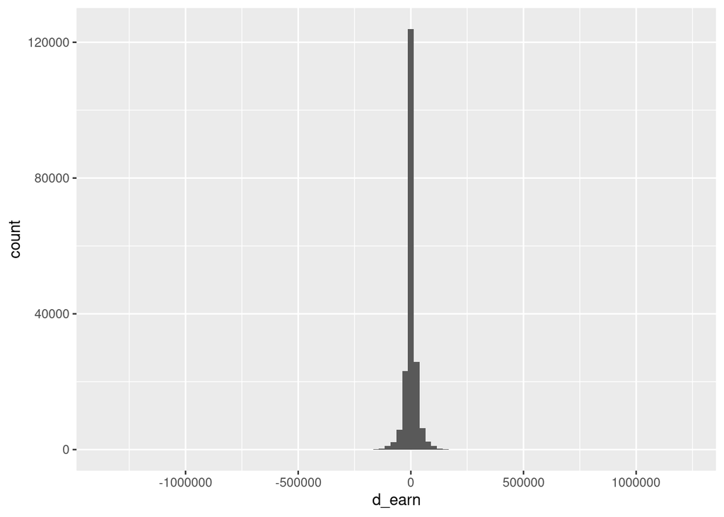

```r
# Plot the histograms for these variables
ggplot(cps_df, aes(x=d_earn)) +
  geom_histogram(bins = 100)
```

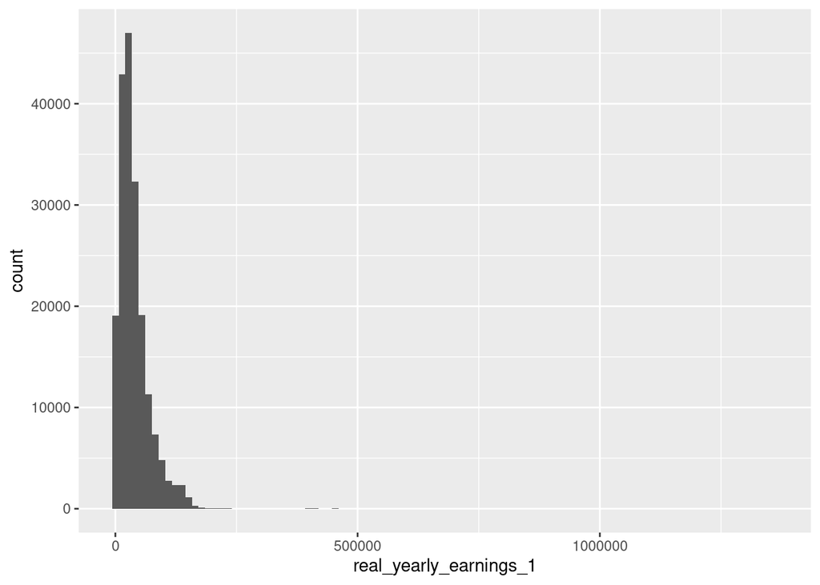

```r
ggplot(cps_df, aes(x=real_yearly_earnings_1)) +
  geom_histogram(bins = 100)
```

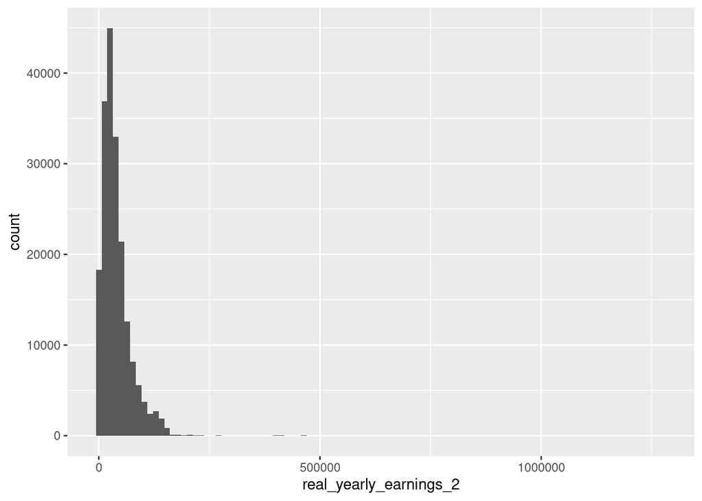

```r
ggplot(cps_df, aes(x=real_yearly_earnings_2)) +
  geom_histogram(bins = 100)
```

As can be seen from the histograms above, `real_yearly_earnings_1` and `real_yearly_earnings_2` variables seem to be heavily right-skewed. We also observe that these two variables have some potentially outlier points on the very right-hand side of the histogram, so we will further investigate these two variables.

### Deal with Missing Values

We begin by checking the number of missing values for our variables of interest, `d_earn`, `real_yearly_earnings_1` and `real_yearly_earnings_2`.

```r
# Check if any of the variables of interest have missing values (i.e. null values)
sum(is.na(cps_df$d_earn))
```

```
## [1] 0
```

```r
sum(is.na(cps_df$real_yearly_earnings_1))
```

```
## [1] 0
```

```r
sum(is.na(cps_df$real_yearly_earnings_2))
```

```
## [1] 0
```

```r
# Across table rows, only 0.18% of them have missing values
sum(is.na(cps_df))/nrow(cps_df)*100
```

```
## [1] 10.95555
```

```r
cps_df <- cps_df %>% drop_na()
sum(is.na(cps_df))/nrow(cps_df)*100
```

```
## [1] 0
```

We observe that none of the variables of interest that we will rely on heavily have any null values, so we do not need to deal with missing values for those columns. We also note that out of all values across all rows (i.e. all observations), only ~10% of them have missing values. Given that it is not a significant percent of the data, we drop these observations (i.e. ~21k out of ~193k observations).

We then proceed with checking for any zero values for `real_yearly_earnings_1` and `real_yearly_earnings_2` as we want to make sure the CPS sample matches the YU sample as closely as possible and so, individuals in the CPS data with no earning data for two consecutive years (which we call year 1 and year 2) are not relevant for building a wage prediction model for the employed YU participants. In addition, we make sure there aren’t any “negative” earnings, which could have been a result of some data entry error.

```r
# Count of observations with year 1 earnings equal to $0
sum(cps_df$real_yearly_earnings_1==0)
```

```
## [1] 6437
```

```r
# Percent of observations with year 1 earnings equal to $0
(sum(cps_df$real_yearly_earnings_1==0) / length(cps_df$d_earn)) * 100
```

```
## [1] 3.735991
```

```r
# Count of observations with year 1 earnings less than $0
sum(cps_df$real_yearly_earnings_1<0)
```

```
## [1] 0
```

```r
# Count of observations with year 2 earnings equal to $0
sum(cps_df$real_yearly_earnings_2==0)
```

```
## [1] 8559
```

```r
# Percent of observations with year 2 earnings equal to $0
(sum(cps_df$real_yearly_earnings_2==0) / length(cps_df$d_earn)) * 100
```

```
## [1] 4.967585
```

```r
# Count of observations with year 2 earnings less than $0
sum(cps_df$real_yearly_earnings_2<0)
```

```
## [1] 0
```

After performing some initial checks, we notice that ~3.7% and ~5.0% of the year 1 earnings and year 2 earnings, respectively, have the value of $0, but neither have values less than $0. To ensure that there are no individuals in the CPS sample who do not have any earnings information, or who do not have any earnings information that is *relevant* for our analysis, we will proceed by filtering out these individuals from our sample.

### Filter observations

We first filter out individuals who have zero values for both `real_yearly_earnings_1` and `real_yearly_earnings_2`. As discussed above, we want to make sure the CPS sample matches the YU sample as closely as possible and so, given that our YU participants are employed, we want to make sure to filter out any CPS individuals who do not have earnings data (or simply do not earn) for two consecutive years (i.e. `real_yearly_earnings_1` and `real_yearly_earnings_2`).

Along the same lines, we decided to filter out any sample with yearly earnings less than $100. It is possible that those earnings were inputted incorrectly– however, even if they were inputted correctly, the participants with less than $100 yearly earnings do not match the YU participants’ earning profiles.

```r
# Count number of year 1 and year 2 earnings with values less than 100
sum(cps_df$real_yearly_earnings_1 <100)
```

```
## [1] 6564
```

```r
sum(cps_df$real_yearly_earnings_2 <100)
```

```
## [1] 8675
```

```r
# Filter out observations with less than $100 yearly earnings (includes observations with $0 earnings as well)
cps_df_filtered <- cps_df[!(cps_df$real_yearly_earnings_1 < 100 | cps_df$real_yearly_earnings_2 < 100)]

# Percent of observations filtered out by removing observations with less than $100 yearly earnings
(length(cps_df$d_earn) - length(cps_df_filtered$d_earn))/ length(cps_df$d_earn) * 100
```

```
## [1] 6.832969
```

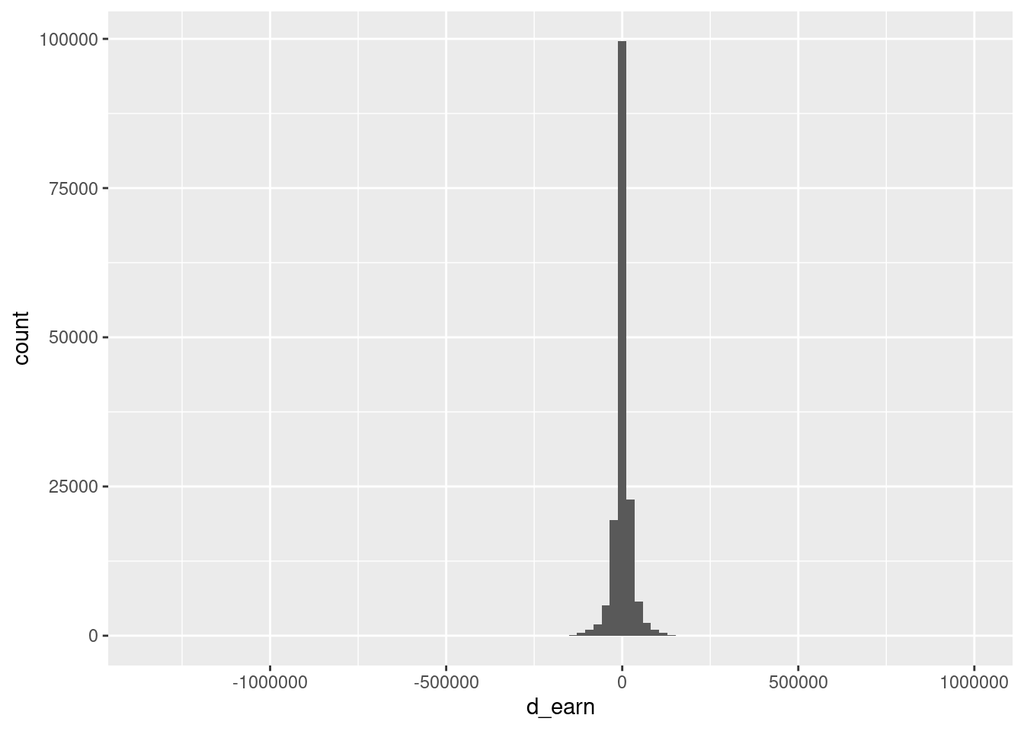

```r
# Histogram of sample earnings, including those with earnings > $150k
ggplot(cps_df_filtered, aes(x=d_earn)) +
  geom_histogram(bins = 100)
```

We have filtered out approx 6.83% of the observations, which had real yearly earnings for either year 1 or year 2, or both, of less than $100.

In addition, observing the statistical summary of the `d_earn` variable above (in the Transforming and pre-processing the data section), we notice that the minimum and maximum of the yearly wage changes are -$1,331,543 and $1,223,313 respectively. This indicates that there could be data inputting errors or that these are individuals with significantly higher earnings than the YU program participants. Because YU is a training program that targets individuals from lower socio-economic backgrounds, we will filter out individuals who earn more than $150,000 annually as they are not a good representative of the YU participant population.

```r
# Filter out observations with more than $150k yearly earnings
cps_df_filtered_2 <- cps_df_filtered[cps_df_filtered$real_yearly_earnings_1 < 150000 & cps_df_filtered$real_yearly_earnings_2 < 150000]

# Percent of observations filtered out with more than $150k yearly earnings
(length(cps_df_filtered$d_earn) - length(cps_df_filtered_2$d_earn))/ length(cps_df_filtered$d_earn) * 100
```

```
## [1] 1.330019
```

```r
# Percent of observations filtered out with more than $150k yearly earnings and less than $100 yearly earnings
(length(cps_df$d_earn) - length(cps_df_filtered_2$d_earn))/ length(cps_df$d_earn) * 100
```

```
## [1] 8.072108
```

Overall, we filtered out ~8.1% of the total observations due to having really low or high yearly earnings (below $100 or above $150,000), which could potentially be due to incorrectly inputted data– but even if these earnings were inputted correctly, they does not match the profiles of the YU participants.

### Investigating Outliers

We can now get a better insight into the potential outlier values observed in the three histograms plotted above. One of the questions that guides our investigation is:

- Are these good or bad outliers? I.e. are these just participants with significantly higher yearly earnings than other participants or are these earnings a result of data inputting errors?

We plot and analyze the histograms of the variables of interest again, just as we have done above.

```r
# Perform a statistical summary of the filtered CPS dataset -- also good sanity check to see if the min/max values are adjusted after we filter out the observations as described above
summary(cps_df_filtered_2$real_yearly_earnings_1)
```

```
##     Min.  1st Qu.   Median     Mean  3rd Qu.     Max.
##    101.3  18593.5  31550.1  38659.8  50818.4 149999.7
```

```r
summary(cps_df_filtered_2$real_yearly_earnings_2)
```

```
##    Min. 1st Qu.  Median    Mean 3rd Qu.    Max.
##     100   19429   32402   39720   52000  150000
```

```r
summary(cps_df_filtered_2$d_earn)
```

```
##      Min.   1st Qu.    Median      Mean   3rd Qu.      Max.
## -145488.1   -6277.4     495.9    1060.5    8524.1  146228.7
```

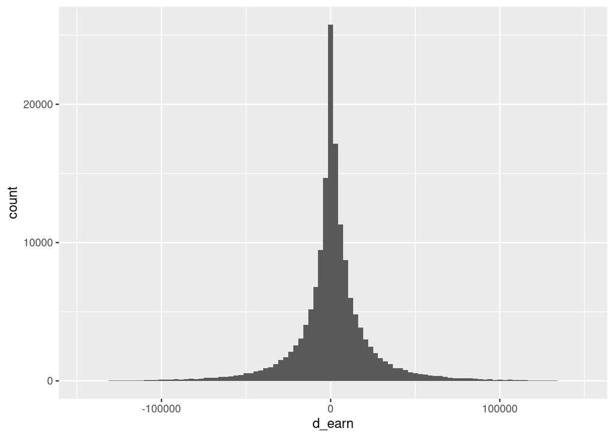

```r
# Histograms after filtering out observations with yearly earnings > $150k and < $100
ggplot(cps_df_filtered_2, aes(x=d_earn)) +
  geom_histogram(bins = 100)
```

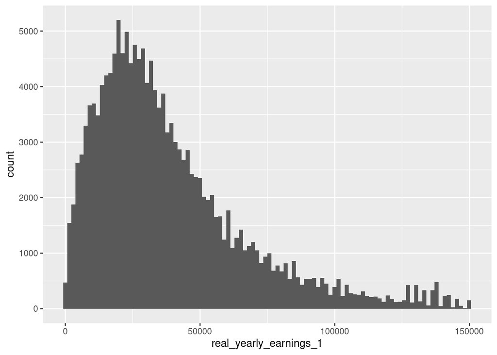

```r
ggplot(cps_df_filtered_2, aes(x=real_yearly_earnings_1)) +
  geom_histogram(bins = 100)
```

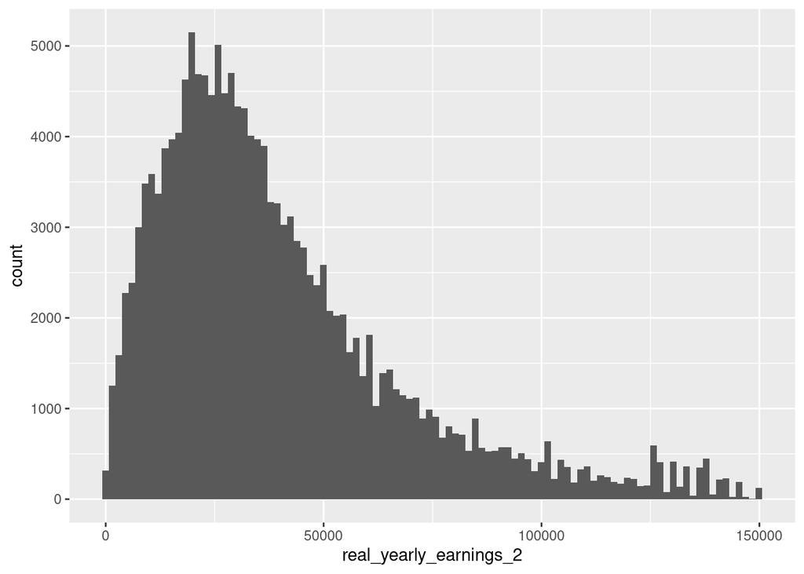

```r
ggplot(cps_df_filtered_2, aes(x=real_yearly_earnings_2)) +
  geom_histogram(bins = 100)
```

As can be seen from the histogram above, even though we only threw out ~8% of the total observations, the range of differences in the yearly earnings shrinks significantly as we filtered out observations that had much higher values than the rest of the observations.

### Apply log transformation on wage change, the dependent variable

We apply a log transformation on the real yearly earnings 1 and 2, `real_yearly_earnings_1` and `real_yearly_earnings_2`, such that the variable `log_d_earn` is the log ratio of the ‘real_yearly_earnings_2’ to ‘real_yearly_earnings_1’ (i.e. log_d_earn = log(real_yearly_earnings_2/real_yearly_earnings_1)). This log transformation is appropriate because it deals with the positively skewed distribution of the yearly earnings variables. Also, note that it is always good practice to add a really small delta to variables before applying a log transformation in order to prevent the log values from “exploding” and becoming NaNs in case the variables have a value of 0. So, although we have filtered out the 0 values, we will still add a delta of 0.001 to the variables `real_yearly_earnings_1` and `real_yearly_earnings_2` for good practice.

```r
# Applying log transformation to real_yearly_earnings_1
cps_df_filtered_log <- cps_df_filtered_2 %>% mutate(real_yearly_earnings_1=if_else(real_yearly_earnings_1==0,0.001,real_yearly_earnings_1),
         log_real_yearly_earnings_1=log(real_yearly_earnings_1))  # ensure real yearly earning is never 0; o.w. log(0) will give NaN values

# Applying log transformation to real_yearly_earnings_2
cps_df_filtered_log <- cps_df_filtered_log %>% mutate(real_yearly_earnings_2=if_else(real_yearly_earnings_2==0,0.001,real_yearly_earnings_2),
         log_real_yearly_earnings_2=log(real_yearly_earnings_2)) # ensure real yearly earning is never 0; o.w. log(0) will give NaN values

# Storing the difference in log yearly earnings as a new variable 'log_d_earn'
cps_df_filtered_log <- cps_df_filtered_log %>% mutate(log_d_earn=log_real_yearly_earnings_2-log_real_yearly_earnings_1)

# Percent of observations with log_d_earn == 0
(sum(cps_df_filtered_log$log_d_earn==0) / length(cps_df_filtered_log$log_d_earn)) * 100
```

```
## [1] 0
```

```r
# Percent of observations with log_real_yearly_earnings_1 == 0.001 (which is the default value we set if log_real_yearly_earnings_1 == 0)
(sum(cps_df_filtered_log$log_real_yearly_earnings_1==0.001) / length(cps_df_filtered_log$log_d_earn)) * 100
```

```
## [1] 0
```

```r
# Percent of observations with log_real_yearly_earnings_2 == 0.001 (which is the default value we set if log_real_yearly_earnings_2 == 0)
(sum(cps_df_filtered_log$log_real_yearly_earnings_2==0.001) / length(cps_df_filtered_log$log_d_earn)) * 100
```

```
## [1] 0
```

```r
# Get the summary statistics for 'log_d_earn', the logged ratio of yearly earnings variable
summary(cps_df_filtered_log$log_d_earn)
```

```
##     Min.  1st Qu.   Median     Mean  3rd Qu.     Max.
## -6.95150 -0.22741  0.01814  0.04268  0.30774  7.07506
```

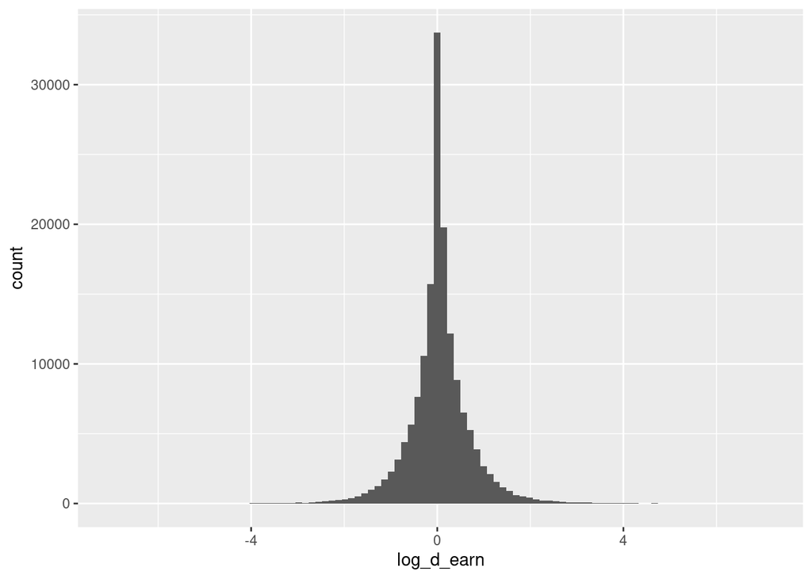

```r
# Histogram of yearly wage change after applying log transformation
ggplot(cps_df_filtered_log, aes(x=log_d_earn)) +
  geom_histogram(bins = 100)
```

As can be observed from the histogram and the summary statistics for ‘log_d_earn’, the log transformation seems reasonable in terms of both the range and distribution of values, so we proceed with building our wage prediction model.

### Scale and center continuous explanatory variables

We initially create a dataframe with the relevant columns for our wage prediction model and if appropriate, convert variables such as region_large (which represents the region size), into categorical ones.

```r
# Create table with relevant columns for building a wage prediction model
cps_df_log<- cps_df_filtered_log %>%
  select(log_d_earn,
         year,cpsidp,occ1digit,age,age2,sex,race_white,race_black,race_asian,
         edu_num, experience,experience2,metfips,
         RTIa,task_abstract,task_routine,task_manual,county,region_large,county_name,cty_pop2000,cz,cz_name,cz_pop2000,intersects_msa,
         cs00_seg_inc,cs00_seg_inc_pov25,cs00_seg_inc_aff75,
         cs_race_theil_2000,gini99,poor_share,inc_share_1perc,
         frac_middleclass,rel_tot,cs_frac_black,
         cs_frac_hisp,unemp_rate,pop_d_2000_1980,lf_d_2000_1980,
         cs_labforce,cs_elf_ind_man,cs_born_foreign,mig_inflow,
         mig_outflow,pop_density,frac_traveltime_lt15,hhinc00,
         median_house_value,cs_educ_ba,
         cs_fam_wkidsinglemom,crime_total,subcty_exp_pc,
         taxrate,tax_st_diff_top20, log_real_yearly_earnings_1)

colnames(cps_df_log)<- c("log_d_earn",
                         "year","cpsidp","occ1digit","age","age2","sex",
                     "race_white","race_black","race_asian","edu_num" ,"experience","experience2",
                     "metfips", "RTIa","task_abstract","task_routine",
                     "task_manual","county","region_large",
                    "county_name","cty_pop2000","cz","cz_name","cz_pop2000","intersects_msa",
                    "cs00_seg_inc","cs00_seg_inc_pov25","cs00_seg_inc_aff75",
                    "cs_race_theil_2000","gini99","poor_share","inc_share_1perc",
                    "frac_middleclass","rel_tot","cs_frac_black",
                    "cs_frac_hisp","unemp_rate","pop_d_2000_1980","lf_d_2000_1980",
                    "cs_labforce","cs_elf_ind_man","cs_born_foreign","mig_inflow",
                    "mig_outflow","pop_density","frac_traveltime_lt15","hhinc00",
                    "median_house_value","cs_educ_ba",
                    "cs_fam_wkidsinglemom","crime_total","subcty_exp_pc",
                    "taxrate","tax_st_diff_top20", "log_real_yearly_earnings_1")

# Convert the CPS table into a dataframe object
class(cps_df_log)<-class(as.data.frame(cps_df_log))

# Store variables to be converted into categorical ones
categorical<-c("year","region_large")
# 'lapply' applies a given function (in this case factor) to each column stored in the 'categorical' variable and converts the variable into a categorical one
cps_df_log[ , categorical] <- lapply(cps_df_log[ ,categorical] , factor)

# Store the relevant CPS data (including log wage change) for building the wage prediction model
vars<- cps_df_log %>%
  select(log_real_yearly_earnings_1, year,
         age,age2,sex,race_white,race_black,race_asian,
         edu_num, experience,experience2,
         RTIa,task_abstract,task_routine,task_manual,region_large,
         cty_pop2000,cs00_seg_inc,cs00_seg_inc_pov25,cs00_seg_inc_aff75,
         cs_race_theil_2000,gini99,poor_share,inc_share_1perc,
         frac_middleclass,rel_tot,cs_frac_black,
         cs_frac_hisp,unemp_rate,pop_d_2000_1980,lf_d_2000_1980,
         cs_labforce,cs_elf_ind_man,cs_born_foreign,mig_inflow,
         mig_outflow,pop_density,frac_traveltime_lt15,hhinc00,
         median_house_value,,cs_educ_ba,
         cs_fam_wkidsinglemom,crime_total,subcty_exp_pc,
         taxrate,tax_st_diff_top20)
saveRDS(vars, file = paste(save_folder, "vars.rds", sep="/"))

# Store the names of the variables used in the wage prediction model as they will come handy when adding new ones
col_vars<-colnames(vars)
control_vars=col_vars
```

Next, we need to split the data into a training and test data set. We do this by drawing a random sample of 80% into the training and 20% into the test dataset. The reason for this splitting is that we want to train our model on the bulk of the data and then check how well our model performs on data the model has never seen. This way we make sure that our model does not overfit (i.e. is too closely modeled on the training dataset but does not generalize well to other datasets). You can read about why 80-20 is the common train-test split standard [here](https://towardsdatascience.com/finally-why-we-use-an-80-20-split-for-training-and-test-data-plus-an-alternative-method-oh-yes-edc77e96295d).

After splitting the dataset, in order to standardize our features,i.e. to center (subtract the mean) and scale (divide by standard deviation) them, we compute those parameters for standardization on the training set (i.e. means and standard deviations of features in the training set) and apply the same parameters on the continuous variables of both the training and test sets. The reason for this standardization is that machine learning algorithms (e.g. linear regression, logistic regression, etc.) use gradient descent as an optimization technique. Gradient descent uses a step size for each feature to update the model parameters (i.e. coefficients) in order to minimize a cost function, which in turn improves our model’s predictive performance. Due to the presence of features X in the gradient descent formula, the values of these features affect the step size of the gradient descent. Thus, the difference in ranges of features leads to different step sizes for each feature. To ensure that the steps for gradient descent are updated at the same rate for all features and that the algorithm moves smoothly towards its convergence point (i.e. minima), we scale the dataset that we feed into our model. See https://ml-cheatsheet.readthedocs.io/en/latest/gradient_descent.html for more on gradient descent.

As a final step, we convert categorical variables into dummy variables. Note that some ML models like random forests do not do well with many dummy variables, which is why here we made an effort to describe any categorical variables (occupation, locations) through continuous variables (e.g. the task index of an occupation or the population density of a region).

```r
# Use train_fraction to split the dataset into training and test sets
train_fraction <- 0.80
n <- dim(cps_df_log)[1]

# Set seed to ensure same training and test set used for model evaluation in different scripts
set.seed(1234)

# Randomly select the specified fraction of indices to be included in the training set
train_idx <- sample.int(n, replace=F, size=floor(n*train_fraction))

# Generate training sample using the 80-20 split rule
cps_df_log_train <- as.data.frame(cps_df_log[train_idx,])
cps_df_log_test <- as.data.frame(cps_df_log[-train_idx,])

# Store the clean CPS (with log wage change) training and test sets without standardization
cps_df_log_train_unscaled <- cps_df_log_train
cps_df_log_test_unscaled <- cps_df_log_test

# Save the unscaled training and test sets as we will need them to build wage prediction model for subgroups in a different tutorial
#saveRDS(cps_df_log_train_unscaled, file = "cps_df_log_train_unscaled.rds")
#saveRDS(cps_df_log_test_unscaled, file = "cps_df_log_test_unscaled.rds")

# Select continuous variables to be scaled
cont<-vars %>%select(-c(year,
                        region_large, sex, race_white,race_black,
                        race_asian))
cont<-c(colnames(cont))

# Compute parameters for standardization on training set
pre_proc_val <- preProcess(cps_df_log_train[,cont], method = c("center", "scale"))

# Save the continuous variables' names (will be used to standardize the YU continous variables)
#saveRDS(cont, file = paste(save_folder, "cont.rds", sep="/"))
# Save the standardization parameters as we will also apply them on the YU data
saveRDS(pre_proc_val, file = paste(save_folder, "pre_proc_val.rds", sep="/"))

# Standardize the continuous variables of the training and test sets by applying the 'pre_proc_val' parameters above
cps_df_log_train[,cont] = predict(pre_proc_val, cps_df_log_train[,cont])
cps_df_log_test[,cont] = predict(pre_proc_val, cps_df_log_test[,cont])

# Ensure CPS data is stored as a dataframe object
class(cps_df_log)<-class(as.data.frame(cps_df_log))

# Make dummy variables for variables of both training and test sets (scaled and unscaled versions)
cols_reg = c(control_vars,'log_d_earn')
dummies <- dummyVars(log_d_earn ~ ., data = cps_df_log[,cols_reg])

cps_log_train_dummies = predict(dummies, newdata = cps_df_log_train[,cols_reg])
cps_log_test_dummies = predict(dummies, newdata = cps_df_log_test[,cols_reg])

cps_log_train_dummies_unscaled = predict(dummies, newdata = cps_df_log_train_unscaled[,cols_reg])
cps_log_test_dummies_unscaled = predict(dummies, newdata = cps_df_log_test_unscaled[,cols_reg])

# Save the scaled training and test sets dummies as we will need them to perform calibration analysis in a different tutorial
#saveRDS(cps_log_train_dummies, file = "cps_log_train_dummies.rds")
#saveRDS(cps_log_test_dummies, file = "cps_log_test_dummies.rds")

# Save the unscaled training and test sets dummies as we will need them to build wage prediction model for subgroups in a different tutorial
#saveRDS(cps_log_train_dummies_unscaled, file = "cps_log_train_dummies_unscaled.rds")
#saveRDS(cps_log_test_dummies_unscaled, file = "cps_log_test_dummies_unscaled.rds")

cols<-colnames(cps_log_train_dummies)

# Save column names to be used in a different tutorial to ensure columns are in the same order across the CPS and YU datasets
saveRDS(cols, file = paste(save_folder, "cols.rds", sep="/"))
```

## The Wage Prediction Model

Having pre-processed the dataset, we are now ready to build the wage prediction model using machine learning algorithms. Having tested a linear, ridge, lasso, and random forest model, we decide on a ridge regression model and show its performance using $R^2$, RMSE, and the standard error on the MSE. The ridge regression model penalizes the sum of squared coefficients and prevents over-fitting by regularizing the model coefficients. The optimal penalization parameter was found with cross-validaton.

```r
# Function to evaluate model performance for regression models
eval_results <- function(true, predicted, df) {
  # Use the definitions of R^2 and RMSE to compute these metrics
  SSE <- sum((true-predicted)^2)
  SST <- sum((true - mean(true))^2)
  R_square <- 1 - SSE / SST
  RMSE = sqrt(SSE/nrow(df))
  SE = (true-predicted)^2
  MSE=SSE/nrow(df)
  std.d_SE= sd(SE)
  std.err_MSE=std.d_SE /sqrt(nrow(df))
  CI_MSE_high= MSE+1.96*std.err_MSE
  CI_MSE_low=   MSE-1.96*std.err_MSE
  # Model performance metrics
  metricsdf<<-data.frame(
    MSE=MSE,
    RMSE = RMSE,
    Rsquare = R_square
  )
  data.frame(
     MSE=MSE,
    RMSE = RMSE,
    Rsquare = R_square
  )

}
eval_results_test <- function(true, predicted, df) {
  # Use the definitions of R^2 and RMSE to compute these metrics
  # for test set evaluation we also add the std error and confidence intervals around the MSE
  SSE <- sum((true-predicted)^2)
  SST <- sum((true - mean(true))^2)
  R_square <- 1 - SSE / SST
  RMSE = sqrt(SSE/nrow(df))
  SE = (true-predicted)^2
  MSE=SSE/nrow(df)
  std.d_SE= sd(SE)
  std.err_MSE=std.d_SE /sqrt(nrow(df))
  CI_MSE_high= MSE+1.96*std.err_MSE
  CI_MSE_low=   MSE-1.96*std.err_MSE
  # Model performance metrics
  metricsdf<<-data.frame(
    MSE=MSE,
    std.err_MSE=std.err_MSE,
    CI_MSE_high=CI_MSE_high,
    CI_MSE_low=CI_MSE_low,
    RMSE = RMSE,
    Rsquare = R_square
  )
  data.frame(
     MSE=MSE,
    std.err_MSE=std.err_MSE,
    CI_MSE_high=CI_MSE_high,
    CI_MSE_low=CI_MSE_low,
    RMSE = RMSE,
    Rsquare = R_square
  )

}
```

```r
# Create the dependent variable 'log_d_earn'
y_train = cps_df_log_train$log_d_earn
y_test = cps_df_log_test$log_d_earn

# Ridge regression model requires the independent variables to be matrix objects
x = as.matrix(cps_log_train_dummies)
x_test = as.matrix(cps_log_test_dummies)

# Initialize lambdas in range [10^2,10^-3] by incrementing the sequence by 10^(-0.1)
lambdas <- 10^seq(2, -3, by = -.1)

# Setting alpha = 0 implements ridge regression
ridge_reg_cps = glmnet(x, y_train, nlambda = 25, alpha = 0, lambda = lambdas, standardize=TRUE)

# Save ridge model to be used in a different tutorial for YU predictions
save(ridge_reg_cps, file = paste(save_folder, "ridge_reg_cps.rda", sep="/"))

# Perform cross-validation to obtain the optimal lambda
cv_ridge <- cv.glmnet(x, y_train, alpha = 0, lambda = lambdas)

# Extract optimal lambda for ridge model
optimal_lambda <- cv_ridge$lambda.min
optimal_lambda
```

```
## [1] 0.001
```

We note that the optimal lambda for our ridge model is 0.001, so we use that lambda parameter when evaluating our model on the test set. We now compute the RMSE and $R^2$ of this ridge model.

```r
# Predict and evaluate on training set
ridge_predictions_train <- predict(ridge_reg_cps, s = optimal_lambda, newx = x)
eval_results(y_train, ridge_predictions_train, cps_df_log_train)
```

```
##         MSE      RMSE   Rsquare
## 1 0.3468059 0.5889023 0.2645458
```

```r
# Predict and evaluate on test set
cps_df_log_test$ridge_predictions_test <- predict(ridge_reg_cps, s = optimal_lambda, newx = x_test)
eval_results_test(y_test, cps_df_log_test$ridge_predictions_test, cps_df_log_test)
```

```
##         MSE std.err_MSE CI_MSE_high CI_MSE_low      RMSE   Rsquare
## 1 0.3517592  0.00581482   0.3631563  0.3403622 0.5930929 0.2632851
```

As we can observe from the $R^2$ and RMSE metrics above, the ridge model performs well on both the training and test sets, which could be explained by the regularization imposed on the coefficients of the regression that makes the model more robust and prevents it from over-fitting. The standard errors and confidence interval around the MSE on the test set tells us how noisy our MSE estimate is, given the sampling variation on the test set. Ideally we would like to get a measure of the MSE on an infinitely large test set. In the absence of that, we include this confidence interval to account for the fact that there is sampling variation. With MSE equal to 0.351, the confidence interval CI_MSE_high and CI_MSE_low tells us that the true estimation of the MSE lies somewhere between 0.363 and 0.340 with 95% confidence.

## Calibration Analysis for Wage Prediction Models

We now show the results of the calibration analysis of the predictions obtained from ridge regression model. Calibration analysis involves comparing the actual output and the expected output given by a model.

### Overall Model Calibration

We begin by performing an overall model calibration analysis to test the robustness of our model. To do so, we plot the actual log yearly wage changes against the predicted log yearly wage changes using the CPS test data. If the plotted line has a slope of 1 then the model is perfectly calibrated; i.e. the model predictions are identical to the actual values. We then compare the plotted line of predicted against actual values with the regression line with slope=1 and intercept=0, which represents a hypothetical, perfectly calibrated line.

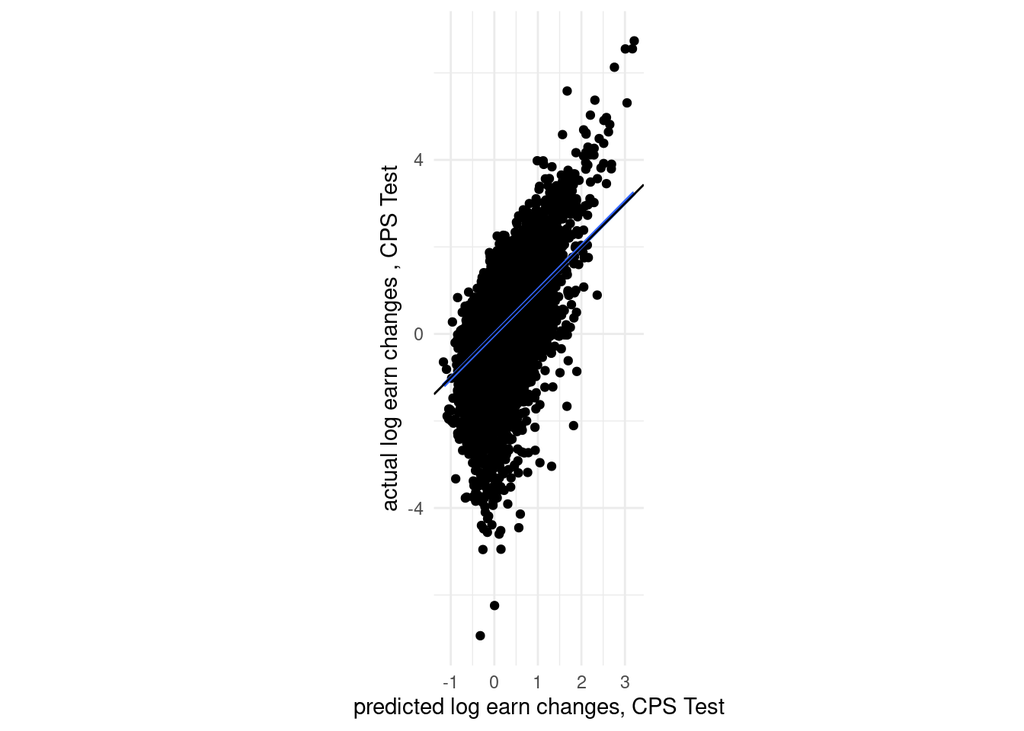

```r
# Plot the ridge regression model line along with a line for a hypothetical, perfectly calibrated model
ggplot(cps_df_log_test, aes(x = ridge_predictions_test, y = log_d_earn)) +
  geom_point() + geom_smooth(method = lm)+ geom_abline(slope=1, intercept = 0) +
  xlab("predicted log earn changes, CPS Test") +
  ylab("actual log earn changes , CPS Test") +
  coord_fixed()+
  theme_minimal()
```

```r
# Run a calibration regression to obtain the slope of the regression model line plotted
summary(lm(log_d_earn~ ridge_predictions_test, data=cps_df_log_test))
```

```
##
## Call:
## lm(formula = log_d_earn ~ ridge_predictions_test, data = cps_df_log_test)
##
## Residuals:
##     Min      1Q  Median      3Q     Max
## -6.6042 -0.2653  0.0484  0.3160  3.8982
##
## Coefficients:
##                         Estimate Std. Error t value            Pr(>|t|)
## (Intercept)            -0.006051   0.003358  -1.802              0.0716 .
## ridge_predictions_test  1.010451   0.009495 106.422 <0.0000000000000002 ***
## ---
## Signif. codes:  0 '***' 0.001 '**' 0.01 '*' 0.05 '.' 0.1 ' ' 1
##
## Residual standard error: 0.5931 on 31676 degrees of freedom
## Multiple R-squared:  0.2634, Adjusted R-squared:  0.2634
## F-statistic: 1.133e+04 on 1 and 31676 DF,  p-value: < 0.00000000000000022
```

The plot above allows us to compare the line of a hypothetical, perfectly-calibrated model (black line) with the line of our ridge wage prediction model (blue line). Using the plot, we can see that the ridge model slope is very close to that of the perfectly calibrated model (as observed by the positioning of the lines as well), which implies that the actual and predicted log yearly earning changes for the ridge model are very similar to each other and thus, the ridge model is well calibrated overall. We also add the regression output that gives the slope of the blue line, i.e. a regression of actual on predicted values. We see that the coefficient is very close to 1, confirming that the model is indeed close to perfectly calibrated.

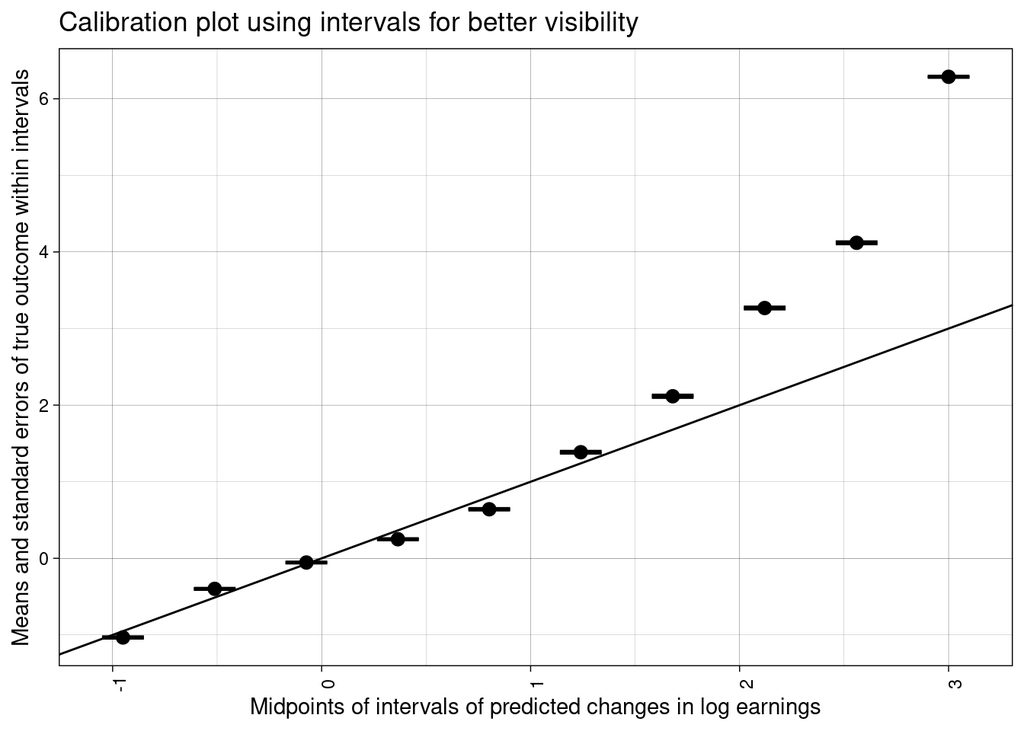

```r
cps_df_log_test<-cps_df_log_test %>%
  mutate(bucket=cut(ridge_predictions_test,breaks = 10))

get_midpoint <- function(cut_label) {
  mean(as.numeric(unlist(strsplit(gsub("\\(|\\)|\\[|\\]", "", as.character(cut_label)), ","))))
}

cps_df_log_test$Midpoint <- sapply(cps_df_log_test$bucket, get_midpoint)

cps_df_log_test_grouped <- cps_df_log_test %>%
  group_by(Midpoint) %>%
  summarise(mean = mean(log_d_earn),
            std = sd(log_d_earn),
            std_err=std/sqrt(dim(cps_df_log_test)[1]))

ggplot(cps_df_log_test_grouped) +
  geom_pointrange(aes(x = Midpoint, y = mean, ymax = mean + 1.96 * std_err, ymin = mean - 1.96 * std_err),
                  size = 0.5) +
  geom_errorbar(aes(x = Midpoint, y = mean, ymax = mean + 1.96 * std_err, ymin = mean - 1.96 * std_err),
                width = 0.2,
                size = 0.7) +
  theme_linedraw() +
    geom_abline(slope=1, intercept = 0)+
  labs(x = "Midpoints of intervals of predicted changes in log earnings", y = "Means and standard errors of true outcome within intervals", title = "Calibration plot using intervals for better visibility")+
    theme(axis.text.x = element_text(angle = 90))
```

### Model Calibration by Subgroups

Having performed an overall model calibration analysis, we will perform the same analysis for different subgroups. We want to make sure that the model is robust and well calibrated not just across all observations but also across different subgroups of observations. Because the lasso and ridge models have performed better than the random forest model, we will use only the former two to perform the calibration by subgroups analysis.

#### Calibration By Gender

We perform calibration analysis by using gender to create subgroups.

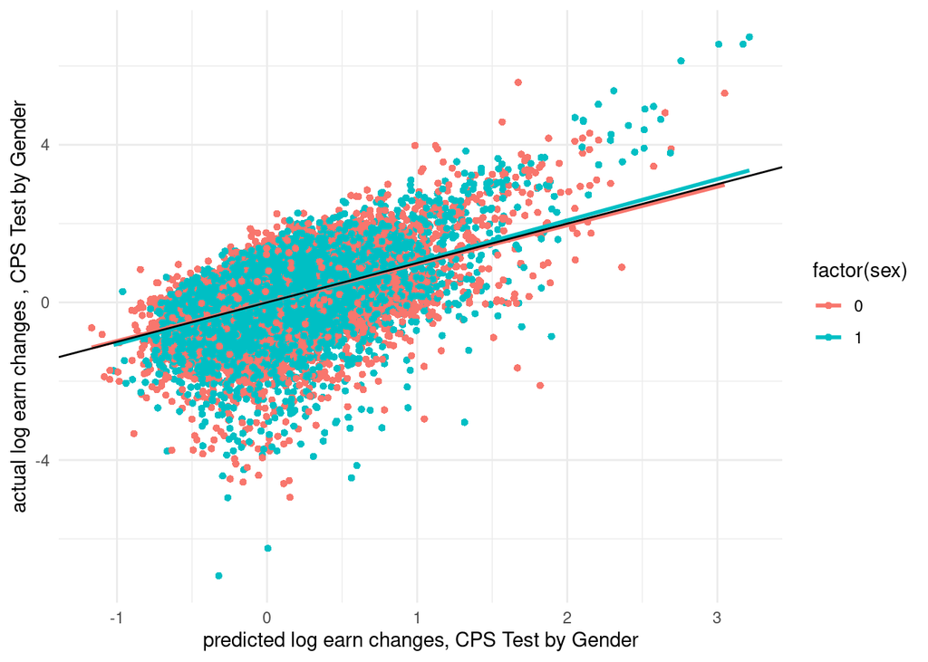

```r
# Plot the ridge regression model line using gender as a subgroup along with a line for a hypothetical, perfectly calibrated model
ggplot(cps_df_log_test, aes(x = ridge_predictions_test, y = log_d_earn, fill=factor(sex))) +
  geom_point(aes(fill=factor(sex)),colour="transparent",shape=21) +
  stat_smooth(aes(colour=factor(sex)),method="lm",se = FALSE) +
  geom_abline(slope=1, intercept = 0) +
  xlab("predicted log earn changes, CPS Test by Gender") +
  ylab("actual log earn changes , CPS Test by Gender") +
  theme_minimal()
```

```r
# Run a calibration regression for male observations to obtain the slope of the regression model line plotted
summary(lm(log_d_earn~ ridge_predictions_test, data=subset(cps_df_log_test, sex==1))) # sex==1 is male
```

```
##
## Call:
## lm(formula = log_d_earn ~ ridge_predictions_test, data = subset(cps_df_log_test,
##     sex == 1))
##
## Residuals:
##     Min      1Q  Median      3Q     Max
## -6.5870 -0.2637  0.0474  0.3176  3.4139
##
## Coefficients:
##                         Estimate Std. Error t value            Pr(>|t|)
## (Intercept)            -0.011773   0.004739  -2.484               0.013 *
## ridge_predictions_test  1.046139   0.013757  76.044 <0.0000000000000002 ***
## ---
## Signif. codes:  0 '***' 0.001 '**' 0.01 '*' 0.05 '.' 0.1 ' ' 1
##
## Residual standard error: 0.5898 on 15731 degrees of freedom
## Multiple R-squared:  0.2688, Adjusted R-squared:  0.2687
## F-statistic:  5783 on 1 and 15731 DF,  p-value: < 0.00000000000000022
```

```r
# Run a calibration regression for female observations to obtain the slope of the regression model line plotted
summary(lm(log_d_earn~ ridge_predictions_test, data=subset(cps_df_log_test, sex==0))) # sex==0 is female
```

```
##
## Call:
## lm(formula = log_d_earn ~ ridge_predictions_test, data = subset(cps_df_log_test,
##     sex == 0))
##
## Residuals:
##     Min      1Q  Median      3Q     Max
## -5.0970 -0.2671  0.0497  0.3148  3.9460
##
## Coefficients:
##                          Estimate Std. Error t value            Pr(>|t|)
## (Intercept)            -0.0004827  0.0047576  -0.101               0.919
## ridge_predictions_test  0.9786064  0.0131214  74.581 <0.0000000000000002 ***
## ---
## Signif. codes:  0 '***' 0.001 '**' 0.01 '*' 0.05 '.' 0.1 ' ' 1
##
## Residual standard error: 0.5961 on 15943 degrees of freedom
## Multiple R-squared:  0.2586, Adjusted R-squared:  0.2586
## F-statistic:  5562 on 1 and 15943 DF,  p-value: < 0.00000000000000022
```

The plot above allows us to compare the line of a hypothetical, perfectly-calibrated model (black line) with the lines of our ridge wage prediction model for male observations (blue line) and for female observations (pink line). Using the plot, we can see that the ridge model slope for female observations is very close to that of the perfectly calibrated model (as observed by the positioning of the lines as well), which implies that the actual and predicted log yearly earning changes of the ridge model for female observations are very similar to each other.

Next, we plot the calibration decile plots for the subgroup of male and females separately. Both plots are equally non-linear, which suggets that the calibrations are not that good for both male and female subgroups; the 3rd-9th decile for males are relatively good, but the female decile plots are a bit less linear.

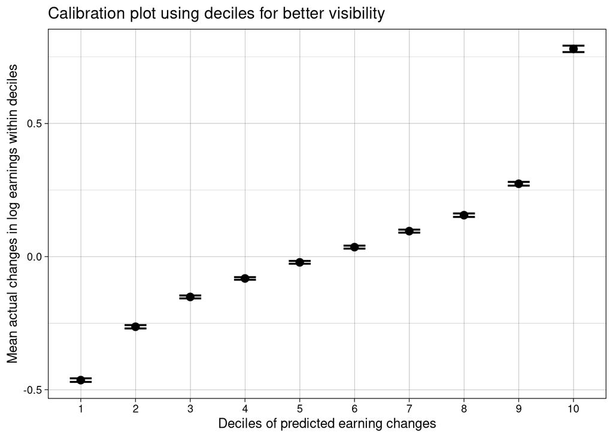

```r
#Male
num_tiles <- 10

cps_df_log_test$ntile <- factor(ntile(cps_df_log_test$ridge_predictions_test, n=num_tiles))
cps_df_log_test_grouped <- cps_df_log_test %>%
  filter(sex == 1) %>%
  group_by(ntile) %>%
  summarise(mean = mean(log_d_earn),
            std = sd(log_d_earn),
            std_err=std/sqrt(dim(cps_df_log_test)[1]))
  ggplot(cps_df_log_test_grouped) +
  geom_pointrange(aes(x = ntile, y = mean, ymax = mean + 1.96 * std_err, ymin = mean - 1.96 * std_err),
                  size = 0.5,
                  position = position_dodge(width = .5)) +
  geom_errorbar(aes(x = ntile, y = mean, ymax = mean + 1.96 * std_err, ymin = mean - 1.96 * std_err),
                width = 0.4,
                size = 0.75,
                position = position_dodge(width = .5)) +
  theme_linedraw() +
  labs(x = "Deciles of predicted earning changes", y = "Mean actual changes in log earnings within deciles", title = "Calibration plot using deciles for better visibility")
```

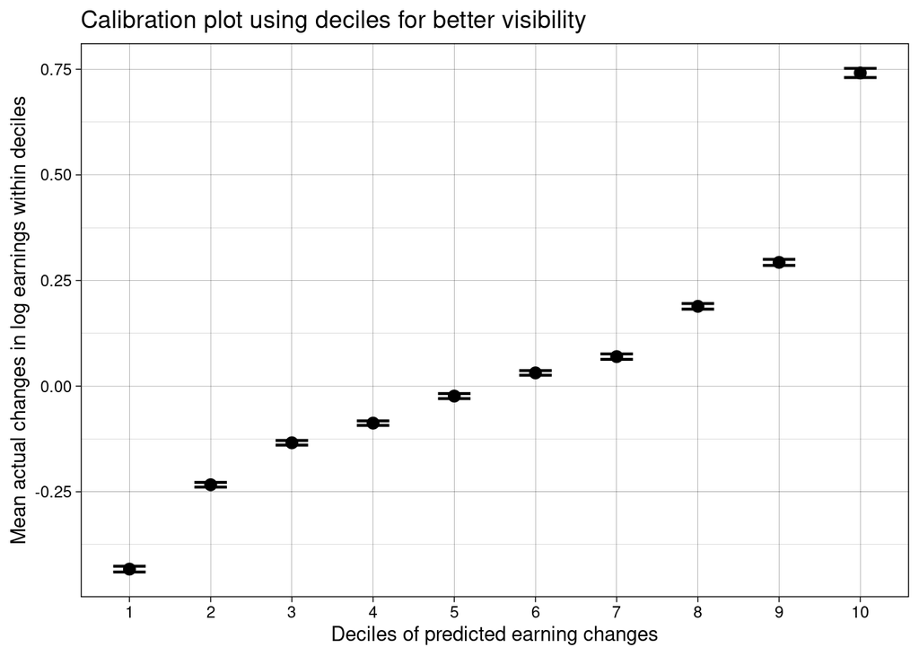

```r
#Female

num_tiles <- 10

cps_df_log_test$ntile <- factor(ntile(cps_df_log_test$ridge_predictions_test, n=num_tiles))
cps_df_log_test_grouped <- cps_df_log_test %>%
  filter(sex == 0) %>%
  group_by(ntile) %>%
  summarise(mean = mean(log_d_earn),
            std = sd(log_d_earn),
            std_err=std/sqrt(dim(cps_df_log_test)[1]))
  ggplot(cps_df_log_test_grouped) +
  geom_pointrange(aes(x = ntile, y = mean, ymax = mean + 1.96 * std_err, ymin = mean - 1.96 * std_err),
                  size = 0.5,
                  position = position_dodge(width = .5)) +
  geom_errorbar(aes(x = ntile, y = mean, ymax = mean + 1.96 * std_err, ymin = mean - 1.96 * std_err),
                width = 0.4,
                size = 0.75,
                position = position_dodge(width = .5)) +
  theme_linedraw() +
  labs(x = "Deciles of predicted earning changes", y = "Mean actual changes in log earnings within deciles", title = "Calibration plot using deciles for better visibility")
```

#### Calibration By Region

We will perform a similar calibration analysis but this time using region size to create subgroups.

```r
# Reverse the scaling of the column representing region's size category to make the plots more understandable
cps_df_log_test$region_large_unscaled <-cps_df_log_test_unscaled$region_large
```

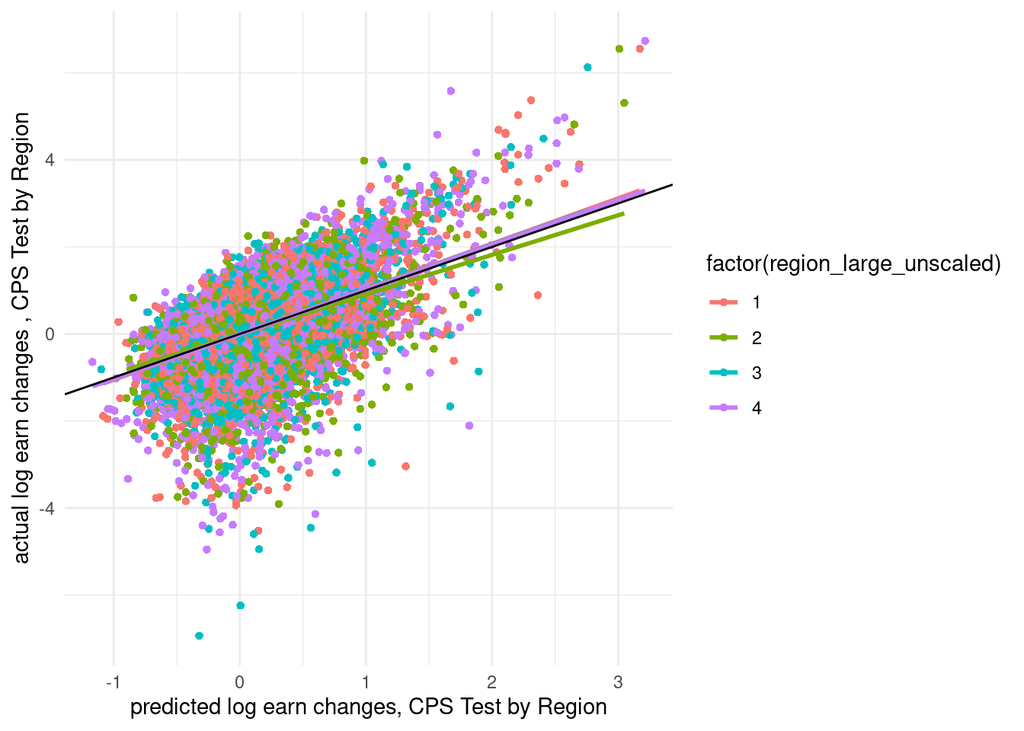

```r
ggplot(cps_df_log_test, aes(x=ridge_predictions_test, y=log_d_earn, fill=factor(region_large_unscaled))) +
  geom_point(aes(fill=factor(region_large_unscaled)),colour="transparent",shape=21) +
  stat_smooth(aes(colour=factor(region_large_unscaled)),method="lm",se = FALSE) +
  geom_abline(slope=1, intercept = 0) +
  xlab("predicted log earn changes, CPS Test by Region") +
  ylab("actual log earn changes , CPS Test by Region") +
  theme_minimal()
```

```r
table(cps_df_log_test$region_large_unscaled)
```

```
##
##     1     2     3     4
##  7565  5376  7242 11495
```

In addition, lines for regions 1 and 3 show that the model predictions are better calibrated for these regions than for region 2; however, they are not as well calibrated as the line for region 4, which is the region with the highest number of observations. This shows the importance of having a balanced set of observations from different subgroups in obtaining a well calibrated model performance across subgroups.

Again, the over- and under-predictions we observe for the ridge model are not large enough to make this model an unfit candidate for the wage prediction model.

```r
# Run a calibration regression for observations with region==1 to obtain the slope of the regression model line plotted
summary(lm(log_d_earn~ ridge_predictions_test, data=subset(cps_df_log_test, region_large_unscaled==1)))
```

```
##
## Call:
## lm(formula = log_d_earn ~ ridge_predictions_test, data = subset(cps_df_log_test,
##     region_large_unscaled == 1))
##
## Residuals:
##     Min      1Q  Median      3Q     Max
## -4.6634 -0.2815  0.0543  0.3285  3.2577
##
## Coefficients:
##                         Estimate Std. Error t value            Pr(>|t|)
## (Intercept)            -0.010682   0.006956  -1.536               0.125
## ridge_predictions_test  1.042287   0.018989  54.890 <0.0000000000000002 ***
## ---
## Signif. codes:  0 '***' 0.001 '**' 0.01 '*' 0.05 '.' 0.1 ' ' 1
##
## Residual standard error: 0.5999 on 7563 degrees of freedom
## Multiple R-squared:  0.2849, Adjusted R-squared:  0.2848
## F-statistic:  3013 on 1 and 7563 DF,  p-value: < 0.00000000000000022
```

```r
# Run a calibration regression for observations with region==2 to obtain the slope of the regression model line plotted
summary(lm(log_d_earn~ ridge_predictions_test, data=subset(cps_df_log_test, region_large_unscaled==2)))
```

```
##
## Call:
## lm(formula = log_d_earn ~ ridge_predictions_test, data = subset(cps_df_log_test,
##     region_large_unscaled == 2))
##
## Residuals:
##     Min      1Q  Median      3Q     Max
## -4.1870 -0.2475  0.0528  0.2968  3.8145
##
## Coefficients:
##                         Estimate Std. Error t value            Pr(>|t|)
## (Intercept)            -0.002345   0.008121  -0.289               0.773
## ridge_predictions_test  0.909863   0.022186  41.010 <0.0000000000000002 ***
## ---
## Signif. codes:  0 '***' 0.001 '**' 0.01 '*' 0.05 '.' 0.1 ' ' 1
##
## Residual standard error: 0.5901 on 5374 degrees of freedom
## Multiple R-squared:  0.2384, Adjusted R-squared:  0.2382
## F-statistic:  1682 on 1 and 5374 DF,  p-value: < 0.00000000000000022
```

```r
# Run a calibration regression for observations with region==3 to obtain the slope of the regression model line plotted
summary(lm(log_d_earn~ ridge_predictions_test, data=subset(cps_df_log_test, region_large_unscaled==3)))
```

```
##
## Call:
## lm(formula = log_d_earn ~ ridge_predictions_test, data = subset(cps_df_log_test,
##     region_large_unscaled == 3))
##
## Residuals:
##     Min      1Q  Median      3Q     Max
## -6.5998 -0.2564  0.0380  0.3149  3.2905
##
## Coefficients:
##                         Estimate Std. Error t value            Pr(>|t|)
## (Intercept)            -0.004029   0.007075  -0.569               0.569
## ridge_predictions_test  1.030529   0.020877  49.362 <0.0000000000000002 ***
## ---
## Signif. codes:  0 '***' 0.001 '**' 0.01 '*' 0.05 '.' 0.1 ' ' 1
##
## Residual standard error: 0.5972 on 7240 degrees of freedom
## Multiple R-squared:  0.2518, Adjusted R-squared:  0.2517
## F-statistic:  2437 on 1 and 7240 DF,  p-value: < 0.00000000000000022
```

```r
# Run a calibration regression for observations with region==4 to obtain the slope of the regression model line plotted
summary(lm(log_d_earn~ ridge_predictions_test, data=subset(cps_df_log_test, region_large_unscaled==4)))
```

```
##
## Call:
## lm(formula = log_d_earn ~ ridge_predictions_test, data = subset(cps_df_log_test,
##     region_large_unscaled == 4))
##
## Residuals:
##     Min      1Q  Median      3Q     Max
## -4.7489 -0.2657  0.0502  0.3162  3.8700
##
## Coefficients:
##                         Estimate Std. Error t value            Pr(>|t|)
## (Intercept)            -0.005911   0.005509  -1.073               0.283
## ridge_predictions_test  1.027242   0.015811  64.972 <0.0000000000000002 ***
## ---
## Signif. codes:  0 '***' 0.001 '**' 0.01 '*' 0.05 '.' 0.1 ' ' 1
##
## Residual standard error: 0.5868 on 11493 degrees of freedom
## Multiple R-squared:  0.2686, Adjusted R-squared:  0.2686
## F-statistic:  4221 on 1 and 11493 DF,  p-value: < 0.00000000000000022
```

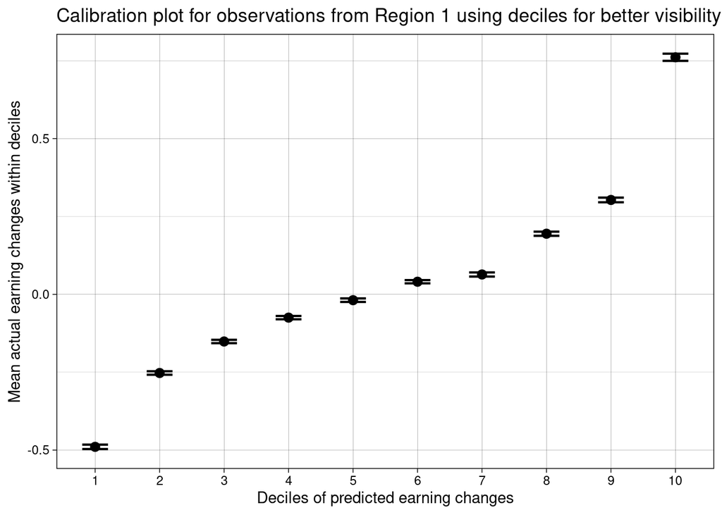

```r
num_tiles <- 10
cps_df_log_test$ntile <- factor(ntile(cps_df_log_test$ridge_predictions_test, n=num_tiles))
cps_df_log_test_grouped <- cps_df_log_test %>%
  dplyr::filter(region_large_unscaled==1) %>%
  group_by(ntile) %>%
  summarise(mean = mean(log_d_earn),
            std = sd(log_d_earn),
            std_err=std/sqrt(dim(cps_df_log_test)[1]))
  ggplot(cps_df_log_test_grouped) +
  geom_pointrange(aes(x = ntile, y = mean, ymax = mean + 1.96 * std_err, ymin = mean - 1.96 * std_err),
                  size = 0.5,
                  position = position_dodge(width = .5)) +
  geom_errorbar(aes(x = ntile, y = mean, ymax = mean + 1.96 * std_err, ymin = mean - 1.96 * std_err),
                width = 0.4,
                size = 0.75,
                position = position_dodge(width = .5)) +
  theme_linedraw() +
  labs(x = "Deciles of predicted earning changes", y = "Mean actual earning changes within deciles", title = "Calibration plot for observations from Region 1 using deciles for better visibility")
```

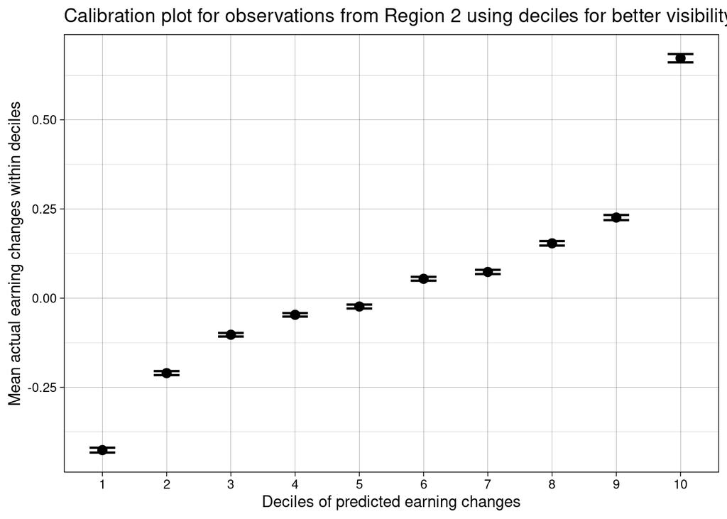

```r
num_tiles <- 10
cps_df_log_test$ntile <- factor(ntile(cps_df_log_test$ridge_predictions_test, n=num_tiles))
cps_df_log_test_grouped <- cps_df_log_test %>%
  dplyr::filter(region_large_unscaled==2) %>%
  group_by(ntile) %>%
  summarise(mean = mean(log_d_earn),
            std = sd(log_d_earn),
            std_err=std/sqrt(dim(cps_df_log_test)[1]))
  ggplot(cps_df_log_test_grouped) +
  geom_pointrange(aes(x = ntile, y = mean, ymax = mean + 1.96 * std_err, ymin = mean - 1.96 * std_err),
                  size = 0.5,
                  position = position_dodge(width = .5)) +
  geom_errorbar(aes(x = ntile, y = mean, ymax = mean + 1.96 * std_err, ymin = mean - 1.96 * std_err),
                width = 0.4,
                size = 0.75,
                position = position_dodge(width = .5)) +
  theme_linedraw() +
  labs(x = "Deciles of predicted earning changes", y = "Mean actual earning changes within deciles", title = "Calibration plot for observations from Region 2 using deciles for better visibility")
```

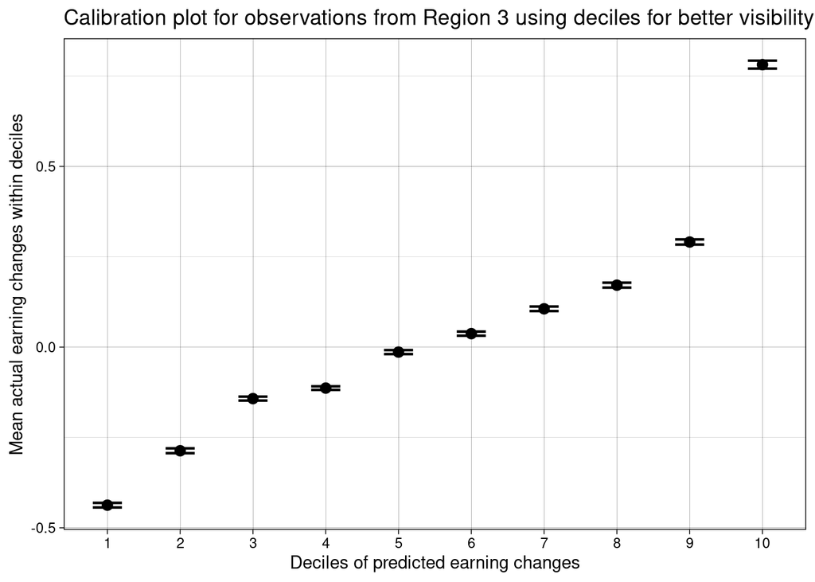

```r
num_tiles <- 10
cps_df_log_test$ntile <- factor(ntile(cps_df_log_test$ridge_predictions_test, n=num_tiles))
cps_df_log_test_grouped <- cps_df_log_test %>%
  dplyr::filter(region_large_unscaled==3) %>%
  group_by(ntile) %>%
  summarise(mean = mean(log_d_earn),
            std = sd(log_d_earn),
            std_err=std/sqrt(dim(cps_df_log_test)[1]))
  ggplot(cps_df_log_test_grouped) +
  geom_pointrange(aes(x = ntile, y = mean, ymax = mean + 1.96 * std_err, ymin = mean - 1.96 * std_err),
                  size = 0.5,
                  position = position_dodge(width = .5)) +
  geom_errorbar(aes(x = ntile, y = mean, ymax = mean + 1.96 * std_err, ymin = mean - 1.96 * std_err),
                width = 0.4,
                size = 0.75,
                position = position_dodge(width = .5)) +
  theme_linedraw() +
  labs(x = "Deciles of predicted earning changes", y = "Mean actual earning changes within deciles", title = "Calibration plot for observations from Region 3 using deciles for better visibility")
```

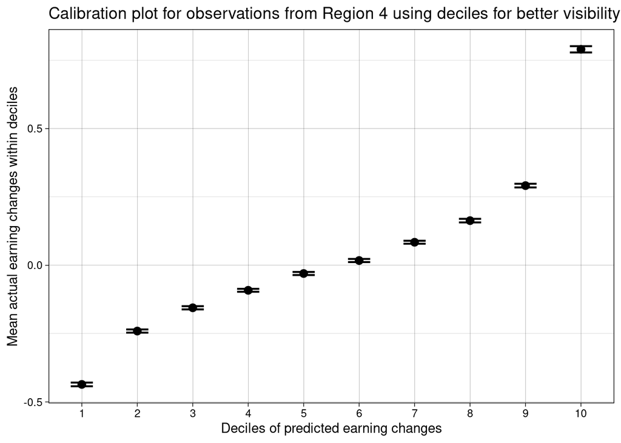

```r
num_tiles <- 10
cps_df_log_test$ntile <- factor(ntile(cps_df_log_test$ridge_predictions_test, n=num_tiles))
cps_df_log_test_grouped <- cps_df_log_test %>%
  dplyr::filter(region_large_unscaled==4) %>%
  group_by(ntile) %>%
  summarise(mean = mean(log_d_earn),
            std = sd(log_d_earn),
            std_err=std/sqrt(dim(cps_df_log_test)[1]))
  ggplot(cps_df_log_test_grouped) +
  geom_pointrange(aes(x = ntile, y = mean, ymax = mean + 1.96 * std_err, ymin = mean - 1.96 * std_err),
                  size = 0.5,
                  position = position_dodge(width = .5)) +
  geom_errorbar(aes(x = ntile, y = mean, ymax = mean + 1.96 * std_err, ymin = mean - 1.96 * std_err),
                width = 0.4,
                size = 0.75,
                position = position_dodge(width = .5)) +
  theme_linedraw() +
  labs(x = "Deciles of predicted earning changes", y = "Mean actual earning changes within deciles", title = "Calibration plot for observations from Region 4 using deciles for better visibility")
```

# Part II: Heterogeneity Analysis

In part II, we use the prediction model we built from a general population in part I to predict wage changes in the Year Up sample, based on their observable characteristics. This gives us our estimate of what the wage changes of Year Up participants would have been had they not participated in the program.

## Steps

1. We load, clean and preprocess the Year-Up data. This includes making sure all the variables have the same names and are coded the same as in the CPS. It is important that the variables in the YearUp data are congruent with the CPS data, because we want to predict counterfactual wages in the Year-Up data from the model built in the CPS.
2. Using the ridge regression model, we predict wage changes for Year-Up participants and thereby build our “control group”.
3. We compare the difference in mean actual outcomes with mean counterfactual predicted outcomes, by building a “treatment effect model”. This gives us the treatment effect, i.e. the return to participating in Year Up on wage changes.
4. Next, we repeat the above exercise for subgroups, and look e.g. at how returns to Year Up differ for men and women.

## Data

We begin by reading in the Year Up data. It comes in two separate files: the records on participants before they started Year Up are in a different dataset from than the post Year Up records. We need to load both and merge them on the “PACE_ID” - which is the unique person identifier. As previously in the case of CPS data, we further “enrich” this data with task and county data, that we merge to participants’ occupations and counties respectively, to have richer information on both. The task data stems from Autor and Dorn’s 2013 paper: “The Growth of Low-Skill Service Jobs and the Polarization of the US Labor Market” and described the routine, manual and abstract task intensity of occupations. More information about the data can be found [here](https://www.ddorn.net/data.htm). The additional location data comes from “Neighborhood Characteristics by County” in Opportunity Insight’s data library which can be found [here](https://opportunityinsights.org/data/).

Since our wage prediction model in the CPS uses these additional variables, we also need them in this dataset.

```r
data_folder <- "Datasets"
save_folder <- "intermediate"

# Load the pre- and post-YU data
df_post<-fread("Datasets/20210119_YU_post_data.csv") #post Year Up records on individuals
df_pre<-fread("Datasets/20210119_YU_pre_data.csv")   #pre Year Up records on individuals

# Load the CPI data
cpi <- read.csv("Datasets/cpi.csv") # yearly consumer price index with which we deflate earnings to USD 2010.

# Load onet crosswalk occupation classifications data
df_xwalk<-fread("Datasets/onet_occ2010_crosswalk.csv") #Year Up occupations have been classified (by our internal algorithm, not shown here - from plein text to onet occupations. Because of our CPS wage prediction model, we need occupations classified with the CPS occ2010 classificaiton. We therefore use a so-called classification crosswalk, which is tells us what the corresponing occ2010 code to each o-net code is.)

# Load occupation digit data
occ1digit<-fread("Datasets/occ1digit.csv")

# Load  task data
yu_tasks<-fread("Datasets/tasks_2010.csv")

# Load FIPS encoding data - to make sure we can merge the files as needed.
metro_fips<-fread("Datasets/fips_site_location.csv")

# Load CPS regions data
region<-fread("Datasets/state_to_region.csv")

# Load county-level data
county_vars<-fread("Datasets/count_level_covars.csv")
```

We first merge the pre- and post-YU data together by the person id (PACE_ID). Then, we add the CPI to the year records, in order to deflate wages and make them constant 2010 USD. Further, we add an occupational encoding crosswalk: Year Up occupations have been classified (by our internal NLP algorithm, not shown here) - from plein text to O NET occupations. Because of our CPS wage prediction model, we need occupations classified with the CPS occ2010 classificaiton. We therefore use a so-called classification crosswalk, which tells us what the corresponing occ2010 code to each O NET code is. We then add the relevant county-level variables to counties as well as task indices to occupations to the Year Up data.

```r
# Merge the pre- and post-YU data
yu_df <- merge(df_post, df_pre,
               by=c("PACE_ID", "Gender", "Race", "Age_at_Start_of_Cohort",
                    "State", "Site", "Edu"),
               all.x = FALSE, all.y = FALSE)
yu_df <- yu_df %>% distinct(PACE_ID, .keep_all = TRUE) #there are a few duplicate pace_ids, which should not be the case - we drop them.

# Rename YU data to have the same names and encodings and CPS data.
yu_df <- yu_df %>%
  mutate(sex=Male_Flag,
         year_pre=Year-1,
         year_post=Year,
         age_pre=Age_at_Start_of_Cohort-1,
         age2_pre=age_pre^2,
         age_post=Age_at_Start_of_Cohort,
         age2_post=age_post^2,
         race_white= if_else(Race=="White",1,0),
         race_black= if_else(Race=="Black or African American",1,0),
         race_asian= if_else(Race=="Asian",1,0),
         edu_num= Edu,
         experience=Exp_4,
         experience2=experience^2)

# Unify naming for pre and post YU jobs and earnings
yu_df <- yu_df %>%
  mutate(occ_onet_pre=ONET_4_Job_preYU,
         earnings_pre=ONET_4_Salary_pre_YU,
         occ_onet_post=ONETCode_post_YU,
         earnings_post=SAL_YU_POSTYU)

# keep only variables of interest
yu_df <- yu_df%>%
  select(PACE_ID,Site,Cohort, sex, race_white,
         race_asian, race_black, edu_num, experience, experience2,
         year_pre, age_pre,age2_pre, occ_onet_pre,earnings_pre,
         year_post,age_post, age2_post,occ_onet_post,earnings_post)


# reshape data from wide to "long", so that we have two entries per individual, pre and post.
yu_df_long<-reshape(yu_df, direction='long',
                    varying=c("age_pre", "age2_pre", "earnings_pre","occ_onet_pre","year_pre",
                               "age_post", "age2_post","earnings_post", "occ_onet_post", "year_post"),
                    timevar='prepost',
                    times=c('1_pre', '2_post'),
                    v.names=c('age', 'age2','earnings','occ_onet', 'year'),
                    idvar='PACE_ID')
```

### Applying log transformation on wages and creation of outcome variable: change in log earnings

We apply a log transformation on the pre and post real yearly earnings 1 and 2 (1 is pre and 2 is post), ‘real_yearly_earnings_1’ and ‘real_yearly_earnings_2’, such that the variable ‘log_d_earn’ is the log ratio of the ‘real_yearly_earnings_2’ to ‘real_yearly_earnings_1’ (i.e. log_d_earn = log(real_yearly_earnings_2/real_yearly_earnings_1)). This log transformation is appropriate because it deals with the positively skewed distribution of the yearly earnings variables. Also, note that while applying this log transformation, we add a delta of 0.001 to these real yearly earnings in order to prevent the log values from “exploding” and becoming NaNs in case the earnings have a value of 0.

```r
## Deflate wages (adjust for inflation) to USD 2010 real wages
# Merge cpi & convert to real values with 2010 base rate
yu_df_long <- left_join(yu_df_long,cpi, by="year", all.x = TRUE)

yu_df_long <- yu_df_long  %>%
  mutate(real_yearly_earnings=earnings/value)

# log transformation of real yearly earnings (in levels), plus inserting a small data in case some earnings are 0.

yu_df_long<-yu_df_long %>%
  mutate(real_yearly_earnings=if_else(real_yearly_earnings==0,0.001,real_yearly_earnings),
         log_earnings=log(real_yearly_earnings))

# Merge onet crosswalk to compare handle CPS occupation coding
yu_df_long<-merge(yu_df_long, df_xwalk, by.x ="occ_onet", by.y ="onet_soc_code", all.x = TRUE)

# Merge YU data with occupation coding data
yu_df_long<-merge(yu_df_long, occ1digit, by= "occ2010", all.x = TRUE)

# Merge YU data with tasks data
yu_df_long<- merge(yu_df_long,yu_tasks,by="occ2010",all.x = TRUE)

# Merge fips encoding
metro_fips<-metro_fips %>% select(-V4, county_fips)
yu_df_long<-merge(yu_df_long,metro_fips, by="Site", all.x = TRUE)

# Merge county level info
county_vars<-county_vars %>%
  select(cty, county_name, cty_pop2000, cz, cz_name, cz_pop2000, intersects_msa,
         cs00_seg_inc, cs00_seg_inc_pov25, cs00_seg_inc_aff75, cs_race_theil_2000,
         gini99, poor_share, inc_share_1perc, frac_middleclass,
         rel_tot, cs_frac_black, cs_frac_hisp, unemp_rate, pop_d_2000_1980,
         lf_d_2000_1980, cs_labforce, cs_elf_ind_man, cs_born_foreign, mig_inflow,
         mig_outflow, pop_density, frac_traveltime_lt15, hhinc00, median_house_value, cs_educ_ba,  cs_fam_wkidsinglemom, crime_total, subcty_exp_pc, taxrate, tax_st_diff_top20)
yu_df_long<-merge(yu_df_long,county_vars, by.x="fips", by.y = "cty", all.x = TRUE)

# Get regions from CPS
yu_df_long<-merge(yu_df_long, region, by.x ="state_fips", by.y ="statefip",all.x = TRUE)

# Get values of occ2010 to restrict to in training data
occuring<-paste(unique(yu_df_long$occ2010), collapse=",")

# Get the occupations of YU partipants before the training program
pre<-yu_df_long %>% filter(prepost=="1_pre")
startocc<-paste(unique(pre$occ2010), collapse=",") # In the first tutorial, this is the vector on which we restrict which occupations we keep in the CPS data - i.e. all occuring starting occupations pre-YU in this data.

# Get the occupations of YU partipants after the training program
post<-yu_df_long %>% filter(prepost=="2_post")
endocc<-paste(unique(post$occ2010), collapse=",")
```

```r
yu_df <- reshape(yu_df_long, direction='wide',
                idvar='PACE_ID',
                timevar= "prepost")

# Log earnings change
yu_df <- yu_df %>%
  mutate(log_d_earn=log_earnings.2_post - log_earnings.1_pre)

# Now that we have generated the earnings change variable, we can keep only one line per individual, the pre-records are enough. Before we do that, let's generate a copy of the datasets with two record per individual, in case we still need it.

yu_df_copy <- yu_df #generate copy
yu_df <- yu_df %>%
  select(PACE_ID, log_d_earn,  log_earnings.2_post, log_earnings.1_pre,
         real_yearly_earnings.1_pre,real_yearly_earnings.2_post, contains("1_pre")) #only keep "pre records"

# Rename variables dropping their prefixes.
colnames(yu_df)<-c("PACE_ID","log_d_earn","log_earnings.2_post", "log_earnings.1_pre", "real_yearly_earnings.1_pre","real_yearly_earnings.2_post","state_fips","fips","Site","occ2010","occ_onet",                    "Cohort","sex", "race_white","race_asian","race_black","edu_num",
                   "experience","experience2","age", "age2", "raw_earnings_pre", "year","value",
                   "occ1digit",
                   "RTIa","task_abstract","task_manual","task_routine","metfips",
                   "metro_name", "County_name", "county_fips","state_name","county_name",
                   "cty_pop2000", "cz","cz_name","cz_pop2000", "intersects_msa","cs00_seg_inc",
                   "cs00_seg_inc_pov25", "cs00_seg_inc_aff75","cs_race_theil_2000",
                   "gini99","poor_share","inc_share_1perc", "frac_middleclass",
                   "rel_tot","cs_frac_black", "cs_frac_hisp","unemp_rate","pop_d_2000_1980",
                   "lf_d_2000_1980","cs_labforce","cs_elf_ind_man","cs_born_foreign",
                   "mig_inflow","mig_outflow","pop_density","frac_traveltime_lt15","hhinc00",
                   "median_house_value",
                   "cs_educ_ba","cs_fam_wkidsinglemom","crime_total",
                   "subcty_exp_pc","taxrate","tax_st_diff_top20", "region_large")
```

### Summary Statistics

Our YU sample consists of all observations for whom we observe pre-and post Year Up (actual) wages, which are denoted by ‘real_yearly_earnings_1’ and ‘real_yearly_earnings_2’, which includes 1469 individuals. By design, the included variables and variable names are identical to those in the CPS data.

```r
# Make a data.frame containing summary statistics of interest
yu_dfsum<-yu_df %>% dplyr::select(log_d_earn, real_yearly_earnings.1_pre,real_yearly_earnings.2_post, where(is.numeric), -c(PACE_ID,value,RTIa, state_fips, fips, log_earnings.1_pre,log_earnings.2_post,cz, raw_earnings_pre,county_fips, metfips))
summ_stats <- fBasics::basicStats(yu_dfsum)
summ_stats <- as.data.frame(t(summ_stats))
# Rename some of the columns for convenience
summ_stats <- summ_stats[c("Mean", "Stdev", "Minimum", "1. Quartile", "Median",  "3. Quartile", "Maximum")]
colnames(summ_stats)[colnames(summ_stats) %in% c('1. Quartile', '3. Quartile')] <- c('Lower quartile', 'Upper quartile')
```

```r
region_summary <- yu_df %>%
  group_by(cz_name) %>%
  summarise(count_yu=n(),
            yu_percent_women=mean(!sex),
            yu_percent_black=mean(race_black),
            yu_percent_black_women=mean(race_black & !sex),
            yu_mean_previous_earnings=mean(real_yearly_earnings.1_pre),
            yu_median_previous_earnings=median(real_yearly_earnings.1_pre),
            yu_log_d_earn_mean=mean(log_d_earn),
            yu_log_d_earn_median=median(log_d_earn),
            yu_age=mean(age),
            yu_edu_num=mean(edu_num),
            yu_mean_task_abstract=mean(task_abstract),
            fraction_middleclass=mean(frac_middleclass),
            fraction_middleclass=mean(cs_frac_black),
            fraction_born_foreign=mean(cs_born_foreign),
            pop_density=mean(pop_density),
            median_house_value=mean(median_house_value),
            tax_rate=mean(taxrate),
            unemployment_rate=mean(unemp_rate),
            inflow=mean(mig_inflow),
            outflow=mean(mig_outflow),
            gini=mean(gini99),
            cty_pop2000=mean(cty_pop2000),
            cz_pop2000=mean(cz_pop2000),
            intersects_msa=mean(intersects_msa),
            cs00_seg_inc=mean(cs00_seg_inc),
            cs00_seg_inc_pov25=mean(cs00_seg_inc_pov25),
            cs00_seg_inc_aff75=mean(cs00_seg_inc_aff75),
            cs_race_theil_2000=mean(cs_race_theil_2000),
            poor_share=mean(poor_share),
            inc_share_1perc=mean(inc_share_1perc),
            rel_tot=mean(rel_tot),
            cs_frac_hisp=mean(cs_frac_hisp),
            pop_d_2000_1980=mean(pop_d_2000_1980),
            lf_d_2000_1980=mean(lf_d_2000_1980),
            cs_labforce=mean(cs_labforce),
            cs_elf_ind_man=mean(cs_elf_ind_man),
            frac_traveltime_lt15=mean(frac_traveltime_lt15),
            hhinc00=mean(hhinc00),cs_educ_ba=mean(cs_educ_ba),
            cs_fam_wkidsinglemom=mean(cs_fam_wkidsinglemom),
            crime_total=mean(crime_total),
            subcty_exp_pc=mean(subcty_exp_pc),
            tax_st_diff_top20=mean(tax_st_diff_top20)
)

#Using cz_name instead of metro_name to make sure it's the same
#region_summary_test <- yu_df %>%
#  group_by(cz_name) %>%
#  summarise(count=n(),
#            percent_women=mean(!sex),
#            percent_black=mean(race_black),
#            percent_black_women=mean(race_black & !sex))

occupation_summary <- yu_df %>%
  group_by(occ1digit) %>%
  summarise(count_yu=n(),
            yu_percent_women=mean(!sex),
            yu_percent_black=mean(race_black),
            yu_percent_black_women=mean(race_black & !sex),
            yu_mean_previous_earnings=mean(real_yearly_earnings.1_pre),
            yu_median_previous_earnings=median(real_yearly_earnings.1_pre),
            yu_log_d_earn_mean=mean(log_d_earn),
            yu_log_d_earn_median=median(log_d_earn),
            yu_age=mean(age),
            yu_edu_num=mean(edu_num),
            fraction_middleclass=mean(frac_middleclass),
            fraction_middleclass=mean(cs_frac_black),
            fraction_born_foreign=mean(cs_born_foreign),
            pop_density=mean(pop_density),
            median_house_value=mean(median_house_value),
            tax_rate=mean(taxrate),
            unemployment_rate=mean(unemp_rate),
            inflow=mean(mig_inflow),
            outflow=mean(mig_outflow),
            gini=mean(gini99)) %>%
  arrange(-count_yu)

write_csv(region_summary, "region_summary.csv")
write_csv(occupation_summary, "occupation_summary.csv")

occupation_region <- yu_df %>%
  group_by(occ1digit,cz_name) %>%
  summarise(count=n(),
            yu_median_previous_earnings=median(real_yearly_earnings.1_pre),
            yu_log_d_earn_median=median(log_d_earn))

write_csv(occupation_region, "occupation_region.csv")
```

```r
# Pretty-printing in HTML
summ_stats_table <- kable(summ_stats, "html", digits = 2)
kable_styling(summ_stats_table,
              bootstrap_options=c("striped", "hover", "condensed", "responsive"),
              full_width=FALSE)
```

|  | Mean | Stdev | Minimum | Lower quartile | Median | Upper quartile | Maximum |
| --- | --- | --- | --- | --- | --- | --- | --- |
| log_d_earn | 0.50 | 0.40 | -4.62 | 0.30 | 0.51 | 0.72 | 1.71 |
| real_yearly_earnings.1_pre | 22525.29 | 58113.50 | 12822.18 | 16284.88 | 18512.00 | 21223.14 | 1484798.33 |
| real_yearly_earnings.2_post | 33803.39 | 11391.72 | 13877.58 | 26790.38 | 31611.84 | 38908.68 | 102138.96 |
| occ2010 | 4609.41 | 2050.75 | 20.00 | 4020.00 | 4720.00 | 5240.00 | 9640.00 |
| sex | 0.57 | 0.49 | 0.00 | 0.00 | 1.00 | 1.00 | 1.00 |
| race_white | 0.04 | 0.20 | 0.00 | 0.00 | 0.00 | 0.00 | 1.00 |
| race_asian | 0.08 | 0.28 | 0.00 | 0.00 | 0.00 | 0.00 | 1.00 |
| race_black | 0.44 | 0.50 | 0.00 | 0.00 | 0.00 | 1.00 | 1.00 |
| edu_num | 12.63 | 0.93 | 12.00 | 12.00 | 12.00 | 14.00 | 14.00 |
| experience | 2.90 | 1.66 | 0.00 | 2.00 | 3.00 | 4.00 | 8.00 |
| experience2 | 11.13 | 11.70 | 0.00 | 4.00 | 9.00 | 16.00 | 64.00 |
| age | 18.90 | 1.66 | 16.00 | 18.00 | 19.00 | 20.00 | 24.00 |
| age2 | 359.82 | 64.34 | 256.00 | 324.00 | 361.00 | 400.00 | 576.00 |
| year | 2014.41 | 3.04 | 2007.00 | 2012.00 | 2015.00 | 2017.00 | 2019.00 |
| task_abstract | 2.36 | 1.81 | 0.00 | 1.41 | 1.94 | 2.28 | 7.62 |
| task_manual | 0.64 | 0.93 | 0.00 | 0.06 | 0.30 | 0.87 | 5.85 |
| task_routine | 3.97 | 2.29 | 1.25 | 2.01 | 3.14 | 6.76 | 8.54 |
| cty_pop2000 | 1324729.70 | 1521042.46 | 236517.00 | 689807.00 | 776733.00 | 1537195.00 | 9519338.00 |
| cz_pop2000 | 5643104.72 | 2991549.99 | 1176696.00 | 3798017.00 | 4642561.00 | 4974945.00 | 16393360.00 |
| intersects_msa | 1.00 | 0.00 | 1.00 | 1.00 | 1.00 | 1.00 | 1.00 |
| cs00_seg_inc | 0.09 | 0.02 | 0.05 | 0.07 | 0.09 | 0.10 | 0.13 |
| cs00_seg_inc_pov25 | 0.08 | 0.03 | 0.03 | 0.06 | 0.08 | 0.10 | 0.12 |
| cs00_seg_inc_aff75 | 0.10 | 0.03 | 0.06 | 0.08 | 0.09 | 0.12 | 0.15 |
| cs_race_theil_2000 | 0.26 | 0.11 | 0.07 | 0.20 | 0.28 | 0.37 | 0.47 |
| gini99 | 0.66 | 0.21 | 0.28 | 0.49 | 0.68 | 0.71 | 1.09 |
| poor_share | 0.14 | 0.05 | 0.04 | 0.10 | 0.13 | 0.19 | 0.23 |
| inc_share_1perc | 0.30 | 0.13 | 0.06 | 0.21 | 0.36 | 0.37 | 0.54 |
| frac_middleclass | 0.46 | 0.05 | 0.36 | 0.43 | 0.47 | 0.48 | 0.56 |
| rel_tot | 51.69 | 13.89 | 28.36 | 41.83 | 55.11 | 60.02 | 73.16 |
| cs_frac_black | 20.82 | 16.96 | 3.36 | 7.57 | 15.27 | 25.86 | 59.45 |
| cs_frac_hisp | 15.47 | 7.91 | 1.83 | 7.86 | 14.10 | 19.93 | 44.56 |
| unemp_rate | 0.05 | 0.01 | 0.02 | 0.04 | 0.05 | 0.06 | 0.06 |
| pop_d_2000_1980 | 0.19 | 0.24 | -0.10 | 0.06 | 0.09 | 0.20 | 1.04 |
| lf_d_2000_1980 | 0.22 | 0.24 | -0.08 | 0.11 | 0.12 | 0.21 | 1.12 |
| cs_labforce | 0.65 | 0.03 | 0.56 | 0.63 | 0.64 | 0.66 | 0.77 |
| cs_elf_ind_man | 0.08 | 0.04 | 0.02 | 0.06 | 0.07 | 0.10 | 0.18 |
| cs_born_foreign | 23.55 | 9.52 | 5.86 | 14.36 | 25.52 | 29.43 | 36.76 |
| mig_inflow | 0.05 | 0.02 | 0.02 | 0.04 | 0.05 | 0.05 | 0.13 |
| mig_outflow | 0.06 | 0.02 | 0.03 | 0.05 | 0.06 | 0.07 | 0.10 |
| pop_density | 15573.21 | 20466.42 | 333.82 | 1658.35 | 11788.35 | 16634.36 | 66940.08 |
| frac_traveltime_lt15 | 0.18 | 0.04 | 0.15 | 0.15 | 0.18 | 0.18 | 0.34 |
| hhinc00 | 48173.63 | 12278.73 | 30716.68 | 37723.32 | 48273.49 | 56014.96 | 69992.70 |
| median_house_value | 435153.30 | 375509.97 | 79580.10 | 209547.60 | 249670.90 | 528401.20 | 1333001.33 |
| cs_educ_ba | 35.45 | 10.08 | 16.60 | 28.00 | 39.00 | 45.00 | 49.40 |
| cs_fam_wkidsinglemom | 0.31 | 0.10 | 0.15 | 0.21 | 0.34 | 0.40 | 0.50 |
| crime_total | 0.01 | 0.00 | 0.00 | 0.01 | 0.01 | 0.01 | 0.02 |
| subcty_exp_pc | 4559.93 | 1958.92 | 1650.76 | 2969.40 | 5065.19 | 5227.67 | 9594.66 |
| taxrate | 0.04 | 0.02 | 0.02 | 0.02 | 0.03 | 0.04 | 0.10 |
| tax_st_diff_top20 | 1.95 | 2.74 | 0.00 | 0.00 | 0.00 | 6.15 | 6.30 |
| region_large | 2.56 | 1.29 | 1.00 | 1.00 | 3.00 | 4.00 | 4.00 |

### Filtering Observations

Next we want to know if there are any outliers in our data, especially in the earnings variables. Outliers can arise from either data entry mistakes or can be true outliers, i.e. an individual who is not at all representative of the rest of the sample. We do not want such observations in the data, since they would bias the analysis. However, before we filter out any observations, we perform some analysis to understand the effect of throwing out these observations on the overall data.

As mentioned in the model building tutorial, an easy way to perform initial outlier analysis is to plot a histogram, so we begin by summarizing and plotting the histogram for the YU data variables of interest– ‘log_d_earn’, which is the difference in yearly log wages, as well as pre and post ‘real_yearly_earnings’, which we use to compute the yearly earnings difference. We then observe the histograms to identify any potential outliers that would require further investigation.

```r
# Perform statistical summaries for the variables of interest
summary(yu_df$log_d_earn)
```

```
##    Min. 1st Qu.  Median    Mean 3rd Qu.    Max.
## -4.6213  0.3005  0.5145  0.5048  0.7247  1.7126
```

```r
summary(yu_df$real_yearly_earnings.1_pre)
```

```
##    Min. 1st Qu.  Median    Mean 3rd Qu.    Max.
##   12822   16285   18512   22525   21223 1484798
```

```r
summary(yu_df$real_yearly_earnings.2_post)
```

```
##    Min. 1st Qu.  Median    Mean 3rd Qu.    Max.
##   13878   26790   31612   33803   38909  102139
```

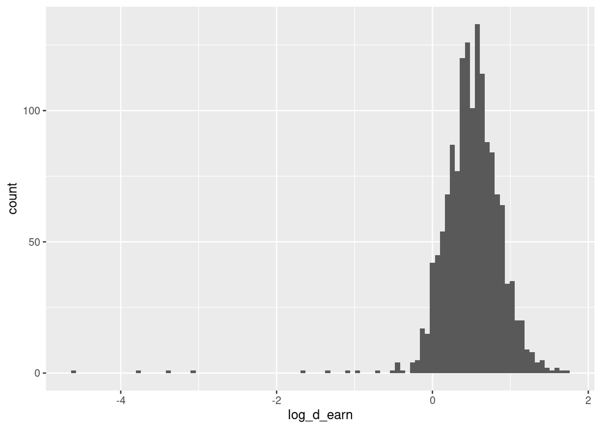

```r
# Plot the histograms for these variables
ggplot(yu_df, aes(x=log_d_earn)) +
  geom_histogram(bins = 100)
```

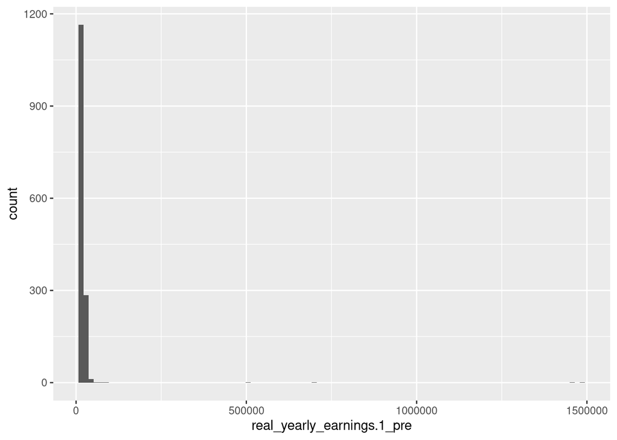

```r
ggplot(yu_df, aes(x=real_yearly_earnings.1_pre)) +
  geom_histogram(bins = 100)
```

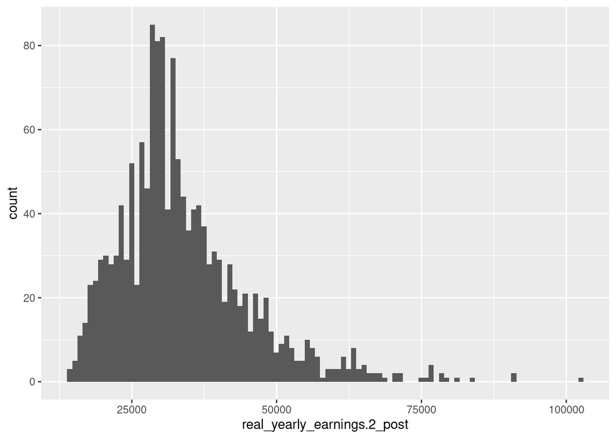

```r
ggplot(yu_df, aes(x=real_yearly_earnings.2_post)) +
  geom_histogram(bins = 100)
```

We can already see that in YU pre-wages, there are some extremely high incomes, that are likely data-entry mistakes. Nobody with incomes over one-million needs to go through the YU program!

```r
# Get the min and max real yearly earnings for YU participants BEFORE the training program
min(yu_df$real_yearly_earnings.1_pre)
```

```
## [1] 12822.18
```

```r
max(yu_df$real_yearly_earnings.1_pre)
```

```
## [1] 1484798
```

```r
# Get the min and max real yearly earnings for YU participants AFTER the training program
min(yu_df$real_yearly_earnings.2_post)
```

```
## [1] 13877.58
```

```r
max(yu_df$real_yearly_earnings.2_post)
```

```
## [1] 102139
```

```r
high_rye <- yu_df[yu_df$real_yearly_earnings.1_pre > 150000 | yu_df$real_yearly_earnings.2_post > 150000]

# Percent change in income after YU training program
((high_rye$real_yearly_earnings.2_post - high_rye$real_yearly_earnings.1_pre) / high_rye$real_yearly_earnings.1_pre) * 100
```

```
## [1] -97.74461 -99.01596 -96.64094 -95.39008
```

```r
sum(yu_df$real_yearly_earnings.1_pre > 100000)
```

```
## [1] 4
```

```r
# Percent of observations with real yearly earnings above USD 100,000 BEFORE the training program
(sum(yu_df$real_yearly_earnings.1_pre>100000) / length(yu_df$real_yearly_earnings.1_pre)) * 100
```

```
## [1] 0.2722941
```

```r
sum(yu_df$real_yearly_earnings.1_pre>150000)
```

```
## [1] 4
```

```r
# Percent of observations with real yearly earnings above USD 150,000 BEFORE the training program
(sum(yu_df$real_yearly_earnings.1_pre>200000) / length(yu_df$real_yearly_earnings.1_pre)) * 100
```

```
## [1] 0.2722941
```

```r
sum(yu_df$real_yearly_earnings.1_pre>500000)
```

```
## [1] 3
```

```r
# Percent of observations with real yearly earnings above USD 500,000 BEFORE the training program
(sum(yu_df$real_yearly_earnings.1_pre>500000) / length(yu_df$real_yearly_earnings.1_pre)) * 100
```

```
## [1] 0.2042206
```

```r
sum(yu_df$real_yearly_earnings.1_pre>1000000)
```

```
## [1] 2
```

```r
# Percent of observations with real yearly earnings above USD 1,000,000 BEFORE the training program
(sum(yu_df$real_yearly_earnings.1_pre>1000000) / length(yu_df$real_yearly_earnings.1_pre))* 100
```

```
## [1] 0.136147
```

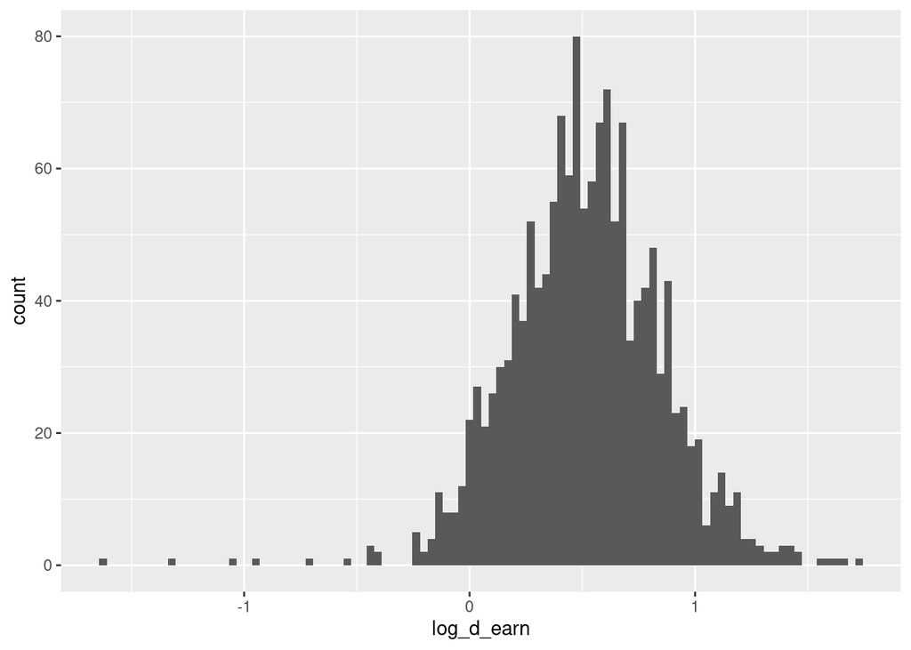

```r
# Filter out observations with real yearly earnings above USD 150,0000
yu_df = yu_df[yu_df$real_yearly_earnings.1_pre <= 150000]

# Plot the histograms for these variables
ggplot(yu_df, aes(x=log_d_earn)) +
  geom_histogram(bins = 100)
```

Observing the summary table, we notice that the maximum real yearly earning pre-YU training program is 1,484,798 which is most likely an outlier and implies that there might be other outliers. We then take a deeper dive into the data to further investigate any other potential outlier.

We then plot the histogram again and notice that the range of ‘log_d_earn’ values significantly shrunk and that the distribution is less skewed than previously when we had the outliers in the data.

### Dealing with Missing Values

```r
# Deal with missing values

# Check how many NAs there are in each variable
pct_na <- function(vec) {
  mean(is.na(vec))
}

sapply(yu_df, pct_na)
```

```
##                     PACE_ID                  log_d_earn
##                  0.00000000                  0.00000000
##         log_earnings.2_post          log_earnings.1_pre
##                  0.00000000                  0.00000000
##  real_yearly_earnings.1_pre real_yearly_earnings.2_post
##                  0.00000000                  0.00000000
##                  state_fips                        fips
##                  0.00000000                  0.00000000
##                        Site                     occ2010
##                  0.00000000                  0.04573379
##                    occ_onet                      Cohort
##                  0.00000000                  0.00000000
##                         sex                  race_white
##                  0.00000000                  0.00000000
##                  race_asian                  race_black
##                  0.00000000                  0.00000000
##                     edu_num                  experience
##                  0.00000000                  0.00000000
##                 experience2                         age
##                  0.00000000                  0.00000000
##                        age2            raw_earnings_pre
##                  0.00000000                  0.00000000
##                        year                       value
##                  0.00000000                  0.00000000
##                   occ1digit                        RTIa
##                  0.12901024                  0.12901024
##               task_abstract                 task_manual
##                  0.12901024                  0.12901024
##                task_routine                     metfips
##                  0.12901024                  0.00000000
##                  metro_name                 County_name
##                  0.00000000                  0.00000000
##                 county_fips                  state_name
##                  0.00000000                  0.00000000
##                 county_name                 cty_pop2000
##                  0.03003413                  0.03003413
##                          cz                     cz_name
##                  0.03003413                  0.03003413
##                  cz_pop2000              intersects_msa
##                  0.03003413                  0.03003413
```

[output cut: 15 more lines]

```
##                  0.03003413                  0.03003413
##             cs_born_foreign                  mig_inflow
##                  0.03003413                  0.03003413
##                 mig_outflow                 pop_density
##                  0.03003413                  0.03003413
##        frac_traveltime_lt15                     hhinc00
##                  0.03003413                  0.03003413
##          median_house_value                  cs_educ_ba
##                  0.03003413                  0.03003413
##        cs_fam_wkidsinglemom                 crime_total
##                  0.03003413                  0.11399317
##               subcty_exp_pc                     taxrate
##                  0.03003413                  0.03003413
##           tax_st_diff_top20                region_large
##                  0.03003413                  0.00000000
```

```r
yu_df  <- na.omit(yu_df ) #drop them

#summarize outcome after dropping NAs
summary(yu_df$log_d_earn)
```

```
##    Min. 1st Qu.  Median    Mean 3rd Qu.    Max.
## -1.3151  0.3032  0.5188  0.5195  0.7363  1.7126
```

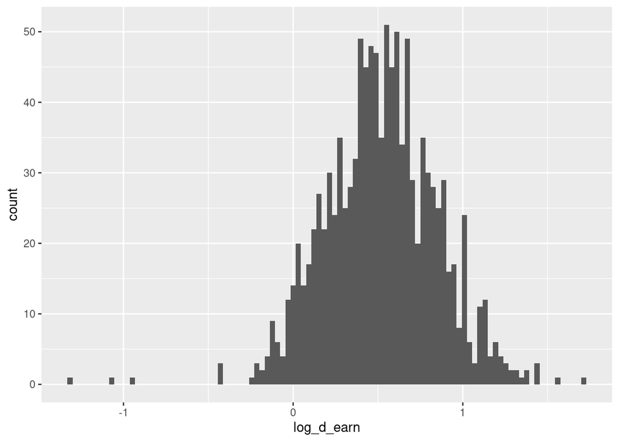

```r
# Plot the histograms for these variables
ggplot(yu_df, aes(x=log_d_earn)) +
  geom_histogram(bins = 100)
```

### Preprocessing the Dataset to Run Model Predictions on YU Data

We created a dataframe with the relevant columns for our wage prediction model and now convert certain variables, such as region_large (which represents the four regions in the US - North East, South, West and Mid-West), into categorical variables where appropriate and then convert those into dummy (or one-hot) variables. Note that with ML models, we want to avoid having too many dummy variables as certain models like random forests do not do well with them. Instead, we make sure that the variables with many categories, such as counties and occupations are instead well described using continous variables like the county neighborhood data and the task data.

Further, we again need to scale the continuous explanatory variables, the same way we did in the CPS. Indeed, we need to scale the data based on the moments of the CPS data, since we trained the model on that data and will be predicting on the YU data.

```r
yu_df<- yu_df%>% rename(log_real_yearly_earnings_1=log_earnings.1_pre)

yu_df = yu_df[, !("occ2010")] # dont need this variable

# Convert variables that are not yet into factors
class(yu_df)<-class(as.data.frame(yu_df))
categorical<-c("year", "region_large")
yu_df[ ,categorical] <- lapply(yu_df[ , categorical] , factor)
```

```r
# Load the CPS variables from memory
vars <- readRDS(paste(save_folder, "vars.rds", sep="/"))
cont <- vars %>% dplyr::select(-c(year, region_large, sex, race_white,
                                race_black, race_asian)) # picking continous variables by exclduing the few categorical variables

# Select the variables from the YU data that match the ones from the CPS data
cont<-c(colnames(cont))
class(yu_df)<-class(as.data.frame(yu_df))

# Load the preprocessed CPS data from memory because we preprocess the YU data
# using the CPS training data preprocessing parameters
pre_proc_val <- readRDS(paste(save_folder, "pre_proc_val.rds", sep="/"))
yu_df[,cont] = predict(pre_proc_val, yu_df[,cont])
```

```r
# Make dummies from all categorical variables
class(yu_df) <- class(as.data.frame(yu_df))
col_vars<-colnames(vars)
control_vars = col_vars

cols_reg = c(control_vars,  'log_d_earn')
dummies <- dummyVars(log_d_earn ~ ., data = yu_df[,cols_reg])
yu_df_dummies = predict(dummies, newdata = yu_df[,cols_reg])

# Manually create one missing category
yu_df_dummies <- as.data.frame(yu_df_dummies)
yu_df_dummies <-yu_df_dummies %>% mutate(year.2006=0)

# Make sure columns are in same order across the CPS and YU datasets
cols <- readRDS(paste(save_folder, "cols.rds", sep="/"))
yu_df_dummies <-yu_df_dummies %>% select(cols)
```

## Using the Ridge Model to Predict Counterfactual Wage Changes in the YU Data

Finally, we can predict counterfactual wages for Year Up participants using our best model we built in the previous tutorial. As we have shown in the model building tutorial, the ridge model performed better than the other models we built and it was also well calibrated, which is why we use the ridge model trained on CPS data get the counterfactual wage change predictions.

We load the ridge model, that we saved in the previous tutorial and also remember that 0.001 was the optimal lambda that we obtained from crossfitting. We then use the ridge model and predict on the YU data as “new data”.

We summarize the predicted values.

```r
# Load the ridge regression model & optimal lambda from memory
load(paste(save_folder, "ridge_reg_cps.rda", sep="/"))

# Use ridge optimal lambda obtained from the model building tutorial
optimal_lambda <- 0.001

# Convert the YU variables to be used as input features into matrix form
yu_df_xdummies = as.matrix(yu_df_dummies)

# Predict on new YU data
yu_log_d_earn_pred <- predict(ridge_reg_cps, s = optimal_lambda, newx = yu_df_xdummies)

#summary(yu_df$log_d_earn)
summary(yu_log_d_earn_pred)
```

```
##        1
##  Min.   :-0.88629
##  1st Qu.:-0.07183
##  Median : 0.04066
##  Mean   : 0.04312
##  3rd Qu.: 0.15198
##  Max.   : 0.57321
```

## Building an Overall Treatment Effect Model

Now that we have the actual yearly earning changes of Year Up participants as well as the counterfactual yearly earning changes (earning changes had they not participated in the training program), we can do the main step of the analysis and compare the two outcomes. To that end, we simply compare the average in actual yearly earning changes to the average in counterfactual yearly earning changes. That is exactly equivalent to regressing yearly earning changes on a treatment indicator, where the treatment indicator shows whether the outcome is the actual (treatment) or counterfactual (control) outcome.

```r
# Define the treatment group in YU data
treatment<-yu_df %>% mutate(treatment=1)

# Define the control group in YU data
control<- yu_df %>% mutate(treatment=0)
control<- control %>% select(-log_d_earn)

# Predict the difference in log yearly earnings for observations in the control group
control$log_d_earn <- predict(ridge_reg_cps, s = optimal_lambda, newx = yu_df_xdummies)

# Combine the treatment and control groups into one dataframe
both<-as.data.frame(rbind(control,treatment))
saveRDS(both, file = paste(save_folder, "yu_treatment_control.rds", sep="/") )

# Regress the difference in log yearly earnings on the treatment group
ate<-lm(log_d_earn~treatment, data=both)
# Summary statistics for the mean treatment effect
summary(ate)
```

```
##
## Call:
## lm(formula = log_d_earn ~ treatment, data = both)
##
## Residuals:
##      Min       1Q   Median       3Q      Max
## -1.83462 -0.14375 -0.00171  0.14811  1.19312
##
## Coefficients:
##             Estimate Std. Error t value             Pr(>|t|)
## (Intercept) 0.043120   0.007706   5.596         0.0000000246 ***
## treatment   0.476382   0.010898  43.713 < 0.0000000000000002 ***
## ---
## Signif. codes:  0 '***' 0.001 '**' 0.01 '*' 0.05 '.' 0.1 ' ' 1
##
## Residual standard error: 0.2593 on 2262 degrees of freedom
## Multiple R-squared:  0.4579, Adjusted R-squared:  0.4577
## F-statistic:  1911 on 1 and 2262 DF,  p-value: < 0.00000000000000022
```

```r
# Get treatment effect by exponentiation of the coefficient of the treatment variable, which is in terms of log wage differences
exp(summary(ate)$coefficients[2,1])
```

```
## [1] 1.610238
```

## Estimating Heterogeneous Treatment Effects for Subgroups

Remember that we are ultimately interested in whether certain subgroups in Year Up participants do better than others. We run one such subgroup analysis here here as an example, and then it will be up to you to investigate other potentially interesting subgroups.

### Treatment Effects by Gender

There are two ways in which we can estimate treatment effects for different subgroups. The first version is to simply split the samples by gender and estimate their respective treatment effects. The second version is to estimate an interaction model, where we interact the treatment indicator with the gender variable.

Let’s start with the first version:

#### Estimating the Treatment Effect for Male participants

```r
ate<-lm(log_d_earn~treatment, data=subset(both,sex==1))

summary(ate)
```

```
##
## Call:
## lm(formula = log_d_earn ~ treatment, data = subset(both, sex ==
##     1))
##
## Residuals:
##      Min       1Q   Median       3Q      Max
## -1.59404 -0.13110 -0.00159  0.13397  0.90715
##
## Coefficients:
##             Estimate Std. Error t value            Pr(>|t|)
## (Intercept) 0.115458   0.009883   11.68 <0.0000000000000002 ***
## treatment   0.422654   0.013977   30.24 <0.0000000000000002 ***
## ---
## Signif. codes:  0 '***' 0.001 '**' 0.01 '*' 0.05 '.' 0.1 ' ' 1
##
## Residual standard error: 0.2479 on 1256 degrees of freedom
## Multiple R-squared:  0.4213, Adjusted R-squared:  0.4208
## F-statistic: 914.4 on 1 and 1256 DF,  p-value: < 0.00000000000000022
```

```r
exp(summary(ate)$coefficients[2,1])
```

```
## [1] 1.526006
```

So it looks like men have a treatment effect of 52% increase in earnings thanks to Year Up.

#### Estimating the Treatment Effect for Female participants

```r
ate<-lm(log_d_earn~treatment, data=subset(both,sex==0))
summary(ate)
```

```
##
## Call:
## lm(formula = log_d_earn ~ treatment, data = subset(both, sex ==
##     0))
##
## Residuals:
##      Min       1Q   Median       3Q      Max
## -1.81135 -0.12217 -0.00936  0.12730  1.21639
##
## Coefficients:
##             Estimate Std. Error t value             Pr(>|t|)
## (Intercept) -0.04734    0.01152   -4.11            0.0000427 ***
## treatment    0.54357    0.01629   33.37 < 0.0000000000000002 ***
## ---
## Signif. codes:  0 '***' 0.001 '**' 0.01 '*' 0.05 '.' 0.1 ' ' 1
##
## Residual standard error: 0.2583 on 1004 degrees of freedom
## Multiple R-squared:  0.5259, Adjusted R-squared:  0.5254
## F-statistic:  1114 on 1 and 1004 DF,  p-value: < 0.00000000000000022
```

```r
exp(summary(ate)$coefficients[2,1])
```

```
## [1] 1.722141
```

#### Estimating an Interaction Model

With such a large difference, it is likely that the difference in treatment effects for men and women is statistically significant. The way to formally test this is to compute confidence intervals (estimate +/- 1.96*standard errorr) around the treatment point-estimates from the standard errors in both regressions, and see whether the confidence intervals overlap. If they do not, then the difference is statistically significant. However, there is also a more direct way to see whether the difference is statistically significant - we can run a joint regression of the whole sample, and interact the treatment effect with gender.

Because of the way our two samples of treatment and control are designed in our case, (i.e. “treatment” and “control” are the same individuals, just with different outcomes - actual and counterfactual) those two approaches will give the same results. This is because the averages in covarariates across the two samples are the same. In the overall average treatment effect regression, this means you can add all the controls you want, and the treatment effect would not change.

If covariates were not the same on average across treatment and control groups, for the subgroup and the interaction effect results to be the same, one would have to interact all included variables with the gender variable. Here the two approaches are identical. The main advantage of the interaction model is that we can see directly whether the difference in treatment effects is statistically significant.

```r
ate<-lm(log_d_earn~treatment + sex*treatment+sex, data = both)

summary(ate)
```

```
##
## Call:
## lm(formula = log_d_earn ~ treatment + sex * treatment + sex,
##     data = both)
##
## Residuals:
##      Min       1Q   Median       3Q      Max
## -1.81135 -0.12645 -0.00546  0.13242  1.21639
##
## Coefficients:
##               Estimate Std. Error t value             Pr(>|t|)
## (Intercept)   -0.04734    0.01126  -4.204         0.0000272707 ***
## treatment      0.54357    0.01593  34.132 < 0.0000000000000002 ***
## sex            0.16280    0.01511  10.776 < 0.0000000000000002 ***
## treatment:sex -0.12091    0.02136  -5.660         0.0000000171 ***
## ---
## Signif. codes:  0 '***' 0.001 '**' 0.01 '*' 0.05 '.' 0.1 ' ' 1
##
## Residual standard error: 0.2526 on 2260 degrees of freedom
## Multiple R-squared:  0.4861, Adjusted R-squared:  0.4854
## F-statistic: 712.5 on 3 and 2260 DF,  p-value: < 0.00000000000000022
```

```r
exp(summary(ate)$coefficients[2,1])
```

```
## [1] 1.722141
```

```r
exp(summary(ate)$coefficients[3,1])
```

```
## [1] 1.176798
```

```r
exp(summary(ate)$coefficients[4,1])
```

```
## [1] 0.8861099
```

It looks like women have a lot larger returns than men from Year Up! Why might that be and what is driving that? This is what we will try to uncover in the third tutorial.

### Treatment Effects by Region

The previous tutorial stated that since some machine learning algorithms do poorly with many dummies, categorical variables like location were expressed as continuous variables that describe the characteristics of the location. This poses a hurdle to exploring heterogeneity by location. In order to explore the location dimension, we will try a few proxies for location, such as population and poverty rate. Unfortunately, this analysis produces coefficients that are hard to interpret. More work is needed to understand which is the proper proxy for location. In the future, we may also try to merge the location dummies back into the data for use in this step (perhaps try region_large?).

```r
ate<-lm(log_d_earn~treatment + cty_pop2000 + cty_pop2000*treatment, data = both)

summary(ate)
```

```
##
## Call:
## lm(formula = log_d_earn ~ treatment + cty_pop2000 + cty_pop2000 *
##     treatment, data = both)
##
## Residuals:
##      Min       1Q   Median       3Q      Max
## -1.84005 -0.14410 -0.00268  0.14714  1.19261
##
## Coefficients:
##                        Estimate Std. Error t value             Pr(>|t|)
## (Intercept)            0.043291   0.007711   5.614         0.0000000222 ***
## treatment              0.476153   0.010905  43.663 < 0.0000000000000002 ***
## cty_pop2000           -0.008757   0.010962  -0.799                0.424
## treatment:cty_pop2000  0.011706   0.015503   0.755                0.450
## ---
## Signif. codes:  0 '***' 0.001 '**' 0.01 '*' 0.05 '.' 0.1 ' ' 1
##
## Residual standard error: 0.2593 on 2260 degrees of freedom
## Multiple R-squared:  0.4581, Adjusted R-squared:  0.4574
## F-statistic: 636.8 on 3 and 2260 DF,  p-value: < 0.00000000000000022
```

```r
paste0("Coefficient on Treatment")
```

```
## [1] "Coefficient on Treatment"
```

```r
exp(summary(ate)$coefficients[2,1])
```

```
## [1] 1.609869
```

```r
paste0("Coefficient on County Population in 2000")
```

```
## [1] "Coefficient on County Population in 2000"
```

```r
exp(summary(ate)$coefficients[3,1])
```

```
## [1] 0.9912814
```

```r
paste0("Coefficient on Interaction")
```

```
## [1] "Coefficient on Interaction"
```

```r
exp(summary(ate)$coefficients[4,1])
```

```
## [1] 1.011775
```

```r
ate<-lm(log_d_earn~treatment + poor_share + poor_share*treatment, data = both)

summary(ate)
```

```
##
## Call:
## lm(formula = log_d_earn ~ treatment + poor_share + poor_share *
##     treatment, data = both)
##
## Residuals:
##      Min       1Q   Median       3Q      Max
## -1.83906 -0.14561 -0.00164  0.14508  1.14993
##
## Coefficients:
##                        Estimate Std. Error t value             Pr(>|t|)
## (Intercept)           0.0429355  0.0086694   4.953          0.000000787 ***
## treatment             0.4964818  0.0122603  40.495 < 0.0000000000000002 ***
## poor_share            0.0003799  0.0083462   0.046             0.963697
## treatment:poor_share -0.0414831  0.0118032  -3.515             0.000449 ***
## ---
## Signif. codes:  0 '***' 0.001 '**' 0.01 '*' 0.05 '.' 0.1 ' ' 1
##
## Residual standard error: 0.258 on 2260 degrees of freedom
## Multiple R-squared:  0.4637, Adjusted R-squared:  0.463
## F-statistic: 651.3 on 3 and 2260 DF,  p-value: < 0.00000000000000022
```

```r
paste0("Coefficient on Treatment")
```

```
## [1] "Coefficient on Treatment"
```

```r
exp(summary(ate)$coefficients[2,1])
```

```
## [1] 1.642931
```

```r
paste0("Coefficient on Poverty Rate")
```

```
## [1] "Coefficient on Poverty Rate"
```

```r
exp(summary(ate)$coefficients[3,1])
```

```
## [1] 1.00038
```

```r
paste0("Coefficient on Interaction")
```

```
## [1] "Coefficient on Interaction"
```

```r
exp(summary(ate)$coefficients[4,1])
```

```
## [1] 0.9593655
```

Here, we explore heterogeneity by occupation. Similar to location, the occupation dummies are expressed as continuous variables. Once again, we use proxies for occupation - measures of how abstract and how manual the tasks in the occupation are. In general, more abstract tasks require a higher education level to accomplish. When we regress earnings using the measure of abstractness, we see that the coeffficient on the treatment and the measure of abstractness are both positive and significant, as we expect them to be. A Year Up applicant coming from a previous occupation that requires more abstract tasks will earn more on average. However, the coefficient on the interaction term is negative and significant. This implies that YearUp is less effective for applicants that come from occupations with more abstract tasks. A possible interpretation for this fact is that these “smarter” applicants would have been able to find lucrative jobs even without going through the program, so the value added of YearUp is low.

We try the same analysis using the measure for how manual the tasks in an occupation are. We assume that occupations with a higher manual score requires less education, so we expect individuals coming from these jobs to benefit significantly from the program. In regression terms, this would translate to a positive interaction term. Running the regression, we find that the interaction term is negative, but not significant. More research is needed to understand these measures, and why the coefficient on the manual measure interaction term is not in the expected direction. Additionally, we hope to find a more systematic way to explore heterogeneity, in order to avoid issues with cherry picking.

```r
ate<-lm(log_d_earn~treatment + task_abstract + task_abstract*treatment, data = both)

summary(ate)
```

```
##
## Call:
## lm(formula = log_d_earn ~ treatment + task_abstract + task_abstract *
##     treatment, data = both)
##
## Residuals:
##      Min       1Q   Median       3Q      Max
## -1.82640 -0.13602  0.00194  0.13794  1.20133
##
## Coefficients:
##                          Estimate Std. Error t value             Pr(>|t|)
## (Intercept)              0.067686   0.007898   8.570 < 0.0000000000000002 ***
## treatment                0.457466   0.011170  40.955 < 0.0000000000000002 ***
## task_abstract            0.092608   0.009023  10.263 < 0.0000000000000002 ***
## treatment:task_abstract -0.071308   0.012761  -5.588         0.0000000257 ***
## ---
## Signif. codes:  0 '***' 0.001 '**' 0.01 '*' 0.05 '.' 0.1 ' ' 1
##
## Residual standard error: 0.2532 on 2260 degrees of freedom
## Multiple R-squared:  0.4833, Adjusted R-squared:  0.4826
## F-statistic: 704.6 on 3 and 2260 DF,  p-value: < 0.00000000000000022
```

```r
paste0("Coefficient on Treatment")
```

```
## [1] "Coefficient on Treatment"
```

```r
exp(summary(ate)$coefficients[2,1])
```

```
## [1] 1.580065
```

```r
paste0("Coefficient on Abstract Task Measure")
```

```
## [1] "Coefficient on Abstract Task Measure"
```

```r
exp(summary(ate)$coefficients[3,1])
```

```
## [1] 1.097032
```

```r
paste0("Coefficient on Interaction")
```

```
## [1] "Coefficient on Interaction"
```

```r
exp(summary(ate)$coefficients[4,1])
```

```
## [1] 0.9311747
```

```r
ate<-lm(log_d_earn~treatment + task_manual + task_manual*treatment, data = both)

summary(ate)
```

```
##
## Call:
## lm(formula = log_d_earn ~ treatment + task_manual + task_manual *
##     treatment, data = both)
##
## Residuals:
##      Min       1Q   Median       3Q      Max
## -1.83246 -0.14267 -0.00157  0.14600  1.19527
##
## Coefficients:
##                        Estimate Std. Error t value             Pr(>|t|)
## (Intercept)            0.045156   0.008490   5.319          0.000000115 ***
## treatment              0.475854   0.012006  39.635 < 0.0000000000000002 ***
## task_manual            0.005997   0.010476   0.573                0.567
## treatment:task_manual -0.001555   0.014815  -0.105                0.916
## ---
## Signif. codes:  0 '***' 0.001 '**' 0.01 '*' 0.05 '.' 0.1 ' ' 1
##
## Residual standard error: 0.2594 on 2260 degrees of freedom
## Multiple R-squared:  0.458,  Adjusted R-squared:  0.4573
## F-statistic: 636.7 on 3 and 2260 DF,  p-value: < 0.00000000000000022
```

```r
paste0("Coefficient on Treatment")
```

```
## [1] "Coefficient on Treatment"
```

```r
exp(summary(ate)$coefficients[2,1])
```

```
## [1] 1.609388
```

```r
paste0("Coefficient on Manual Task Measure")
```

```
## [1] "Coefficient on Manual Task Measure"
```

```r
exp(summary(ate)$coefficients[3,1])
```

```
## [1] 1.006015
```

```r
paste0("Coefficient on Interaction")
```

```
## [1] "Coefficient on Interaction"
```

```r
exp(summary(ate)$coefficients[4,1])
```

```
## [1] 0.9984462
```

### Treatment Effects by Race

#### Count

```r
#White

ate<-lm(log_d_earn~treatment, data=subset(both,race_white==1))
summary(ate)
```

```
##
## Call:
## lm(formula = log_d_earn ~ treatment, data = subset(both, race_white ==
##     1))
##
## Residuals:
##     Min      1Q  Median      3Q     Max
## -0.7036 -0.1531 -0.0085  0.1278  0.8134
##
## Coefficients:
##             Estimate Std. Error t value            Pr(>|t|)
## (Intercept)  0.10931    0.03990   2.739             0.00734 **
## treatment    0.52259    0.05643   9.260 0.00000000000000578 ***
## ---
## Signif. codes:  0 '***' 0.001 '**' 0.01 '*' 0.05 '.' 0.1 ' ' 1
##
## Residual standard error: 0.2793 on 96 degrees of freedom
## Multiple R-squared:  0.4718, Adjusted R-squared:  0.4663
## F-statistic: 85.75 on 1 and 96 DF,  p-value: 0.000000000000005777
```

```r
exp(summary(ate)$coefficients[2,1])
```

```
## [1] 1.686392
```

```r
#Asian

ate<-lm(log_d_earn~treatment, data=subset(both,race_asian==1))
summary(ate)
```

```
##
## Call:
## lm(formula = log_d_earn ~ treatment, data = subset(both, race_asian ==
##     1))
##
## Residuals:
##      Min       1Q   Median       3Q      Max
## -0.72471 -0.15701  0.01662  0.13587  1.10994
##
## Coefficients:
##             Estimate Std. Error t value             Pr(>|t|)
## (Intercept)  0.08412    0.02567   3.277              0.00123 **
## treatment    0.51855    0.03631  14.282 < 0.0000000000000002 ***
## ---
## Signif. codes:  0 '***' 0.001 '**' 0.01 '*' 0.05 '.' 0.1 ' ' 1
##
## Residual standard error: 0.2606 on 204 degrees of freedom
## Multiple R-squared:    0.5,  Adjusted R-squared:  0.4975
## F-statistic:   204 on 1 and 204 DF,  p-value: < 0.00000000000000022
```

```r
exp(summary(ate)$coefficients[2,1])
```

```
## [1] 1.679598
```

```r
#Black

ate<-lm(log_d_earn~treatment, data=subset(both,race_black==1))
summary(ate)
```

```
##
## Call:
## lm(formula = log_d_earn ~ treatment, data = subset(both, race_black ==
##     1))
##
## Residuals:
##      Min       1Q   Median       3Q      Max
## -1.80360 -0.14492  0.01024  0.14594  0.78743
##
## Coefficients:
##             Estimate Std. Error t value             Pr(>|t|)
## (Intercept)  0.04795    0.01255   3.819             0.000143 ***
## treatment    0.44054    0.01775  24.813 < 0.0000000000000002 ***
## ---
## Signif. codes:  0 '***' 0.001 '**' 0.01 '*' 0.05 '.' 0.1 ' ' 1
##
## Residual standard error: 0.269 on 916 degrees of freedom
## Multiple R-squared:  0.402,  Adjusted R-squared:  0.4013
## F-statistic: 615.7 on 1 and 916 DF,  p-value: < 0.00000000000000022
```

```r
exp(summary(ate)$coefficients[2,1])
```

```
## [1] 1.553539
```

```r
#Non-Black
ate<-lm(log_d_earn~treatment, data=subset(both,race_black==0))
summary(ate)
```

```
##
## Call:
## lm(formula = log_d_earn ~ treatment, data = subset(both, race_black ==
##     0))
##
## Residuals:
##      Min       1Q   Median       3Q      Max
## -0.78428 -0.14759 -0.00788  0.14127  1.17196
##
## Coefficients:
##             Estimate Std. Error t value             Pr(>|t|)
## (Intercept) 0.039827   0.009696   4.108            0.0000424 ***
## treatment   0.500830   0.013712  36.526 < 0.0000000000000002 ***
## ---
## Signif. codes:  0 '***' 0.001 '**' 0.01 '*' 0.05 '.' 0.1 ' ' 1
##
## Residual standard error: 0.2515 on 1344 degrees of freedom
## Multiple R-squared:  0.4982, Adjusted R-squared:  0.4978
## F-statistic:  1334 on 1 and 1344 DF,  p-value: < 0.00000000000000022
```

```r
exp(summary(ate)$coefficients[2,1])
```

```
## [1] 1.65009
```

```r
#Interaction Terms

#White

ate<-lm(log_d_earn~treatment + race_white*treatment+race_white, data = both)

summary(ate)
```

```
##
## Call:
## lm(formula = log_d_earn ~ treatment + race_white * treatment +
##     race_white, data = both)
##
## Residuals:
##      Min       1Q   Median       3Q      Max
## -1.82953 -0.14294 -0.00008  0.14766  1.19820
##
## Coefficients:
##                      Estimate Std. Error t value             Pr(>|t|)
## (Intercept)          0.040125   0.007859   5.105          0.000000358 ***
## treatment            0.474291   0.011115  42.672 < 0.0000000000000002 ***
## race_white           0.069180   0.037775   1.831               0.0672 .
## treatment:race_white 0.048300   0.053422   0.904               0.3660
## ---
## Signif. codes:  0 '***' 0.001 '**' 0.01 '*' 0.05 '.' 0.1 ' ' 1
##
## Residual standard error: 0.2586 on 2260 degrees of freedom
## Multiple R-squared:  0.461,  Adjusted R-squared:  0.4603
## F-statistic: 644.4 on 3 and 2260 DF,  p-value: < 0.00000000000000022
```

```r
exp(summary(ate)$coefficients[2,1])
```

```
## [1] 1.606875
```

```r
exp(summary(ate)$coefficients[3,1])
```

```
## [1] 1.071629
```

```r
exp(summary(ate)$coefficients[4,1])
```

```
## [1] 1.049486
```

```r
#Asian

ate<-lm(log_d_earn~treatment + race_asian*treatment+race_asian, data = both)

summary(ate)
```

```
##
## Call:
## lm(formula = log_d_earn ~ treatment + race_asian * treatment +
##     race_asian, data = both)
##
## Residuals:
##      Min       1Q   Median       3Q      Max
## -1.82629 -0.14647  0.00071  0.14366  1.10994
##
## Coefficients:
##                      Estimate Std. Error t value             Pr(>|t|)
## (Intercept)           0.03902    0.00806   4.841           0.00000138 ***
## treatment             0.47216    0.01140  41.422 < 0.0000000000000002 ***
## race_asian            0.04511    0.02672   1.688               0.0915 .
## treatment:race_asian  0.04639    0.03779   1.228               0.2197
## ---
## Signif. codes:  0 '***' 0.001 '**' 0.01 '*' 0.05 '.' 0.1 ' ' 1
##
## Residual standard error: 0.2586 on 2260 degrees of freedom
## Multiple R-squared:  0.4614, Adjusted R-squared:  0.4607
## F-statistic: 645.3 on 3 and 2260 DF,  p-value: < 0.00000000000000022
```

```r
exp(summary(ate)$coefficients[2,1])
```

```
## [1] 1.603455
```

```r
exp(summary(ate)$coefficients[3,1])
```

```
## [1] 1.046139
```

```r
exp(summary(ate)$coefficients[4,1])
```

```
## [1] 1.047487
```

```r
#Black

ate<-lm(log_d_earn~treatment + race_black*treatment+race_black, data = both)

summary(ate)
```

```
##
## Call:
## lm(formula = log_d_earn ~ treatment + race_black * treatment +
##     race_black, data = both)
##
## Residuals:
##      Min       1Q   Median       3Q      Max
## -1.80360 -0.14670  0.00016  0.14346  1.17196
##
## Coefficients:
##                       Estimate Std. Error t value             Pr(>|t|)
## (Intercept)           0.039827   0.009974   3.993            0.0000672 ***
## treatment             0.500830   0.014105  35.508 < 0.0000000000000002 ***
## race_black            0.008119   0.015663   0.518              0.60424
## treatment:race_black -0.060295   0.022150  -2.722              0.00654 **
## ---
## Signif. codes:  0 '***' 0.001 '**' 0.01 '*' 0.05 '.' 0.1 ' ' 1
##
## Residual standard error: 0.2587 on 2260 degrees of freedom
## Multiple R-squared:  0.4606, Adjusted R-squared:  0.4599
## F-statistic: 643.4 on 3 and 2260 DF,  p-value: < 0.00000000000000022
```

```r
exp(summary(ate)$coefficients[2,1])
```

```
## [1] 1.65009
```

```r
exp(summary(ate)$coefficients[3,1])
```

```
## [1] 1.008152
```

```r
exp(summary(ate)$coefficients[4,1])
```

```
## [1] 0.9414871
```

### Treatment Effects by Age

median(treatment$age) = -1.634626 = Age 19 mean(treatment$age) = -1.63576 = Age 19

#### Count

table(treatment$age < -1.634626) = 730 table(treatment$age > -1.634626) = 402

```r
# Age of < -1.6 should be close to median of 19 years of age or less
ate<-lm(log_d_earn~treatment, data=subset(both, age < -1.634626))
summary(ate)
```

```
##
## Call:
## lm(formula = log_d_earn ~ treatment, data = subset(both, age <
##     -1.634626))
##
## Residuals:
##      Min       1Q   Median       3Q      Max
## -1.82556 -0.12740  0.00438  0.13935  1.20217
##
## Coefficients:
##             Estimate Std. Error t value            Pr(>|t|)
## (Intercept) 0.011658   0.009197   1.268               0.205
## treatment   0.498789   0.013006  38.349 <0.0000000000000002 ***
## ---
## Signif. codes:  0 '***' 0.001 '**' 0.01 '*' 0.05 '.' 0.1 ' ' 1
##
## Residual standard error: 0.2485 on 1458 degrees of freedom
## Multiple R-squared:  0.5022, Adjusted R-squared:  0.5018
## F-statistic:  1471 on 1 and 1458 DF,  p-value: < 0.00000000000000022
```

```r
exp(summary(ate)$coefficients[2,1])
```

```
## [1] 1.646726
```

```r
# Age of > -1.6 should be close to median of 19 years of age or more
ate<-lm(log_d_earn~treatment, data=subset(both, age > -1.634626))
summary(ate)
```

```
##
## Call:
## lm(formula = log_d_earn ~ treatment, data = subset(both, age >
##     -1.634626))
##
## Residuals:
##      Min       1Q   Median       3Q      Max
## -1.59187 -0.16153 -0.00958  0.16186  0.89497
##
## Coefficients:
##             Estimate Std. Error t value             Pr(>|t|)
## (Intercept)  0.10025    0.01362    7.36    0.000000000000457 ***
## treatment    0.43569    0.01926   22.62 < 0.0000000000000002 ***
## ---
## Signif. codes:  0 '***' 0.001 '**' 0.01 '*' 0.05 '.' 0.1 ' ' 1
##
## Residual standard error: 0.2731 on 802 degrees of freedom
## Multiple R-squared:  0.3894, Adjusted R-squared:  0.3887
## F-statistic: 511.5 on 1 and 802 DF,  p-value: < 0.00000000000000022
```

```r
exp(summary(ate)$coefficients[2,1])
```

```
## [1] 1.546034
```

```r
#Interaction Terms

ate<-lm(log_d_earn~treatment + age*treatment+age, data = both)

summary(ate)
```

```
##
## Call:
## lm(formula = log_d_earn ~ treatment + age * treatment + age,
##     data = both)
##
## Residuals:
##      Min       1Q   Median       3Q      Max
## -1.83474 -0.13531  0.00339  0.14304  1.20884
##
## Coefficients:
##               Estimate Std. Error t value           Pr(>|t|)
## (Intercept)    0.80540    0.10539   7.642 0.0000000000000314 ***
## treatment     -0.10400    0.14905  -0.698              0.485
## age            0.46601    0.06426   7.252 0.0000000000005631 ***
## treatment:age -0.35481    0.09088  -3.904 0.0000973569370277 ***
## ---
## Signif. codes:  0 '***' 0.001 '**' 0.01 '*' 0.05 '.' 0.1 ' ' 1
##
## Residual standard error: 0.2563 on 2260 degrees of freedom
## Multiple R-squared:  0.4709, Adjusted R-squared:  0.4702
## F-statistic: 670.6 on 3 and 2260 DF,  p-value: < 0.00000000000000022
```

```r
exp(summary(ate)$coefficients[2,1])
```

```
## [1] 0.901223
```

```r
exp(summary(ate)$coefficients[3,1])
```

```
## [1] 1.593624
```

```r
exp(summary(ate)$coefficients[4,1])
```

```
## [1] 0.7013064
```

### Treatment Effects by Years of Education

#### Count

12 years of education = 764 14 years of education = 368

```r
#12 years of education
ate<-lm(log_d_earn~treatment, data=subset(both,edu_num < 0))
summary(ate)
```

```
##
## Call:
## lm(formula = log_d_earn ~ treatment, data = subset(both, edu_num <
##     0))
##
## Residuals:
##      Min       1Q   Median       3Q      Max
## -1.81393 -0.12464 -0.00613  0.13424  1.21381
##
## Coefficients:
##             Estimate Std. Error t value            Pr(>|t|)
## (Intercept) -0.01121    0.00918  -1.221               0.222
## treatment    0.51002    0.01298  39.286 <0.0000000000000002 ***
## ---
## Signif. codes:  0 '***' 0.001 '**' 0.01 '*' 0.05 '.' 0.1 ' ' 1
##
## Residual standard error: 0.2537 on 1526 degrees of freedom
## Multiple R-squared:  0.5028, Adjusted R-squared:  0.5025
## F-statistic:  1543 on 1 and 1526 DF,  p-value: < 0.00000000000000022
```

```r
exp(summary(ate)$coefficients[2,1])
```

```
## [1] 1.665318
```

```r
#14 years of education
ate<-lm(log_d_earn~treatment, data=subset(both,edu_num > 0))
summary(ate)
```

```
##
## Call:
## lm(formula = log_d_earn ~ treatment, data = subset(both, edu_num >
##     0))
##
## Residuals:
##      Min       1Q   Median       3Q      Max
## -0.76153 -0.13869  0.00394  0.13030  1.00178
##
## Coefficients:
##             Estimate Std. Error t value            Pr(>|t|)
## (Intercept)  0.15590    0.01303   11.96 <0.0000000000000002 ***
## treatment    0.40656    0.01843   22.06 <0.0000000000000002 ***
## ---
## Signif. codes:  0 '***' 0.001 '**' 0.01 '*' 0.05 '.' 0.1 ' ' 1
##
## Residual standard error: 0.25 on 734 degrees of freedom
## Multiple R-squared:  0.3987, Adjusted R-squared:  0.3979
## F-statistic: 486.7 on 1 and 734 DF,  p-value: < 0.00000000000000022
```

```r
exp(summary(ate)$coefficients[2,1])
```

```
## [1] 1.501636
```

```r
#Interaction Terms
ate<-lm(log_d_earn~treatment + edu_num*treatment+edu_num, data = both)

summary(ate)
```

```
##
## Call:
## lm(formula = log_d_earn ~ treatment + edu_num * treatment + edu_num,
##     data = both)
##
## Residuals:
##      Min       1Q   Median       3Q      Max
## -1.81393 -0.12957 -0.00285  0.13286  1.21381
##
## Coefficients:
##                   Estimate Std. Error t value             Pr(>|t|)
## (Intercept)        0.12655    0.01097  11.537 < 0.0000000000000002 ***
## treatment          0.42473    0.01551  27.379 < 0.0000000000000002 ***
## edu_num            0.18185    0.01744  10.429 < 0.0000000000000002 ***
## treatment:edu_num -0.11259    0.02466  -4.566           0.00000524 ***
## ---
## Signif. codes:  0 '***' 0.001 '**' 0.01 '*' 0.05 '.' 0.1 ' ' 1
##
## Residual standard error: 0.2525 on 2260 degrees of freedom
## Multiple R-squared:  0.4862, Adjusted R-squared:  0.4856
## F-statistic:   713 on 3 and 2260 DF,  p-value: < 0.00000000000000022
```

```r
exp(summary(ate)$coefficients[2,1])
```

```
## [1] 1.529175
```

```r
exp(summary(ate)$coefficients[3,1])
```

```
## [1] 1.199438
```

```r
exp(summary(ate)$coefficients[4,1])
```

```
## [1] 0.8935191
```

### Treatment Effects by Years of Experiences

#### Count

3+ years of experience = 612 <3 years of experience = 520

```r
# > or = 3 years of experience
ate<-lm(log_d_earn~treatment, data=subset(both,experience > -1.38456474221906))
summary(ate)
```

```
##
## Call:
## lm(formula = log_d_earn ~ treatment, data = subset(both, experience >
##     -1.38456474221906))
##
## Residuals:
##      Min       1Q   Median       3Q      Max
## -1.84550 -0.15623  0.00142  0.14709  0.90054
##
## Coefficients:
##             Estimate Std. Error t value             Pr(>|t|)
## (Intercept)  0.08832    0.01082   8.161 0.000000000000000818 ***
## treatment    0.44206    0.01530  28.883 < 0.0000000000000002 ***
## ---
## Signif. codes:  0 '***' 0.001 '**' 0.01 '*' 0.05 '.' 0.1 ' ' 1
##
## Residual standard error: 0.2677 on 1222 degrees of freedom
## Multiple R-squared:  0.4057, Adjusted R-squared:  0.4052
## F-statistic: 834.2 on 1 and 1222 DF,  p-value: < 0.00000000000000022
```

```r
exp(summary(ate)$coefficients[2,1])
```

```
## [1] 1.555908
```

```r
# < 3 years of experience
ate<-lm(log_d_earn~treatment, data=subset(both,experience < -1.38456474221906))
summary(ate)
```

```
##
## Call:
## lm(formula = log_d_earn ~ treatment, data = subset(both, experience <
##     -1.38456474221906))
##
## Residuals:
##      Min       1Q   Median       3Q      Max
## -1.46059 -0.12230 -0.00063  0.13153  1.20592
##
## Coefficients:
##             Estimate Std. Error t value            Pr(>|t|)
## (Intercept) -0.01008    0.01068  -0.944               0.346
## treatment    0.51678    0.01511  34.210 <0.0000000000000002 ***
## ---
## Signif. codes:  0 '***' 0.001 '**' 0.01 '*' 0.05 '.' 0.1 ' ' 1
##
## Residual standard error: 0.2436 on 1038 degrees of freedom
## Multiple R-squared:   0.53,  Adjusted R-squared:  0.5295
## F-statistic:  1170 on 1 and 1038 DF,  p-value: < 0.00000000000000022
```

```r
exp(summary(ate)$coefficients[2,1])
```

```
## [1] 1.676615
```

```r
#Interaction Terms
ate<-lm(log_d_earn~treatment + experience*treatment+experience, data = both)

summary(ate)
```

```
##
## Call:
## lm(formula = log_d_earn ~ treatment + experience * treatment +
##     experience, data = both)
##
## Residuals:
##      Min       1Q   Median       3Q      Max
## -1.83474 -0.13531  0.00339  0.14304  1.20884
##
## Coefficients:
##                      Estimate Std. Error t value           Pr(>|t|)
## (Intercept)           0.68453    0.08878   7.711 0.0000000000000186 ***
## treatment            -0.01197    0.12555  -0.095              0.924
## experience            0.46288    0.06383   7.252 0.0000000000005631 ***
## treatment:experience -0.35242    0.09027  -3.904 0.0000973569370277 ***
## ---
## Signif. codes:  0 '***' 0.001 '**' 0.01 '*' 0.05 '.' 0.1 ' ' 1
##
## Residual standard error: 0.2563 on 2260 degrees of freedom
## Multiple R-squared:  0.4709, Adjusted R-squared:  0.4702
## F-statistic: 670.6 on 3 and 2260 DF,  p-value: < 0.00000000000000022
```

```r
exp(summary(ate)$coefficients[2,1])
```

```
## [1] 0.9880981
```

```r
exp(summary(ate)$coefficients[3,1])
```

```
## [1] 1.588636
```

```r
exp(summary(ate)$coefficients[4,1])
```

```
## [1] 0.7029824
```

```r
#Interaction Terms
ate<-lm(log_d_earn~treatment + Cohort*treatment+Cohort, data = both)

summary(ate)
```

```
##
## Call:
## lm(formula = log_d_earn ~ treatment + Cohort * treatment + Cohort,
##     data = both)
##
## Residuals:
##      Min       1Q   Median       3Q      Max
## -1.85477 -0.14257 -0.00243  0.14192  1.14946
##
## Coefficients:
##                         Estimate Std. Error t value Pr(>|t|)
## (Intercept)             0.054585   0.255698   0.213   0.8310
## treatment               0.772740   0.361612   2.137   0.0327 *
## CohortJan 09           -0.108104   0.263568  -0.410   0.6817
## CohortJan 10           -0.027143   0.260762  -0.104   0.9171
## CohortJan 11           -0.086509   0.261198  -0.331   0.7405
## CohortJan 12           -0.004968   0.259431  -0.019   0.9847
## CohortJan 13            0.029528   0.259131   0.114   0.9093
## CohortJan 14            0.016129   0.258243   0.062   0.9502
## CohortJan 15            0.041038   0.257856   0.159   0.8736
## CohortJan 16           -0.034994   0.258875  -0.135   0.8925
## CohortJan 17            0.010616   0.257599   0.041   0.9671
## CohortJan 18            0.030396   0.257397   0.118   0.9060
## CohortJan 19           -0.033779   0.257571  -0.131   0.8957
## CohortJan 20           -0.027730   0.258588  -0.107   0.9146
## CohortJul 08           -0.154975   0.265351  -0.584   0.5593
## CohortJul 09           -0.040580   0.262013  -0.155   0.8769
## CohortJul 10           -0.079155   0.262013  -0.302   0.7626
## CohortJul 11           -0.034680   0.259041  -0.134   0.8935
## CohortJul 12           -0.008146   0.259543  -0.031   0.9750
## CohortJul 13            0.046354   0.258588   0.179   0.8577
## CohortJul 14            0.018774   0.258588   0.073   0.9421
## CohortJul 15            0.012822   0.257688   0.050   0.9603
## CohortJul 16           -0.010717   0.257720  -0.042   0.9668
## CohortJul 17           -0.032586   0.257291  -0.127   0.8992
## CohortJul 18           -0.021505   0.256986  -0.084   0.9333
## CohortJul 19           -0.040514   0.257420  -0.157   0.8750
## CohortJul 20           -0.087916   0.361612  -0.243   0.8079
## treatment:CohortJan 09 -0.293212   0.372741  -0.787   0.4316
## treatment:CohortJan 10 -0.307172   0.368773  -0.833   0.4050
```

[output cut: 14 more lines]

```
## treatment:CohortJul 12 -0.356493   0.367050  -0.971   0.3315
## treatment:CohortJul 13 -0.364082   0.365698  -0.996   0.3196
## treatment:CohortJul 14 -0.360058   0.365698  -0.985   0.3249
## treatment:CohortJul 15 -0.251774   0.364426  -0.691   0.4897
## treatment:CohortJul 16 -0.223756   0.364470  -0.614   0.5393
## treatment:CohortJul 17 -0.231577   0.363865  -0.636   0.5246
## treatment:CohortJul 18 -0.266170   0.363434  -0.732   0.4640
## treatment:CohortJul 19 -0.239860   0.364047  -0.659   0.5100
## treatment:CohortJul 20 -0.281624   0.511396  -0.551   0.5819
## ---
## Signif. codes:  0 '***' 0.001 '**' 0.01 '*' 0.05 '.' 0.1 ' ' 1
##
## Residual standard error: 0.2557 on 2212 degrees of freedom
## Multiple R-squared:  0.4844, Adjusted R-squared:  0.4725
## F-statistic: 40.75 on 51 and 2212 DF,  p-value: < 0.00000000000000022
```

```r
exp(summary(ate)$coefficients[2,1])
```

```
## [1] 2.165692
```

```r
exp(summary(ate)$coefficients[3,1])
```

```
## [1] 0.8975346
```

```r
exp(summary(ate)$coefficients[4,1])
```

```
## [1] 0.9732219
```

```r
# January start date
ate<-lm(log_d_earn~treatment, data=subset(both,Cohort<"Jan."))
summary(ate)
```

```
##
## Call:
## lm(formula = log_d_earn ~ treatment, data = subset(both, Cohort <
##     "Jan."))
##
## Residuals:
##     Min      1Q  Median      3Q     Max
## -1.5754 -0.1426 -0.0048  0.1400  1.0447
##
## Coefficients:
##             Estimate Std. Error t value             Pr(>|t|)
## (Intercept)  0.05055    0.01103   4.584           0.00000509 ***
## treatment    0.46895    0.01560  30.069 < 0.0000000000000002 ***
## ---
## Signif. codes:  0 '***' 0.001 '**' 0.01 '*' 0.05 '.' 0.1 ' ' 1
##
## Residual standard error: 0.256 on 1076 degrees of freedom
## Multiple R-squared:  0.4566, Adjusted R-squared:  0.4561
## F-statistic: 904.1 on 1 and 1076 DF,  p-value: < 0.00000000000000022
```